# **TUTORIAL ETE3 EVOL**

# 1. Comprueba que todas las aplicaciones externas estén disponibles

```python
!ete3 build check
```

```
Current Toolchain path: /home/alex/miniconda3/envs/ete3/bin/ete3_apps/bin
Current Toolchain version: unknown
       clustalo: OK - 1.2.4
         codeml: OK - AAML in paml version 4.8a, July 2014
      dialigntx: OK - This is DIALIGN-TX Version 1.0.2 - A Multiple Sequence alignment program.
       fasttree: OK - FastTree Version 2.1.8 Double precision (No SSE3), OpenMP (1 threads)
         iqtree: OK - IQ-TREE multicore version 1.5.5 for Linux 64-bit built Jun  2 2017
         kalign: OK - Kalign version 2.04, Copyright (C) 2004, 2005, 2006 Timo Lassmann
          mafft: OK - MAFFT v6.861b (2011/09/24)
         muscle: OK - MUSCLE v3.8.31 by Robert C. Edgar
          phyml: OK - . This is PhyML version 20160115.
     pmodeltest: OK - pmodeltest.py v1.4
          raxml: OK - This is RAxML version 8.2.11 released by Alexandros Stamatakis on June 2017.
 raxml-pthreads: OK - This is RAxML version 8.2.11 released by Alexandros Stamatakis on June 2017.
         readal: OK - readAl v1.4.rev6 build[2012-02-02]
            slr: OK - # SLR "Sitewise Likelihood Ratio" selection detection program. Version 1.4.3
         statal: OK - statAl v1.4.rev6 build[2012-02-02]
        tcoffee: OK - PROGRAM: T-COFFEE Version_11.00.8cbe486 (2014-08-12 22:05:29 - Revision 8cbe486 - Build 477)
         trimal: OK - trimAl v1.4.rev6 build[2012-02-02]
```

# 2. Lista de flujos de trabajo para árboles filogenéticos

```python
!ete3 build workflows genetree
```

```
-------------------------------------------------------------------------------------------------------------------------
                                             GeneTree shortcut workflow names
-------------------------------------------------------------------------------------------------------------------------
Worflow name                                  | Description                                                  | threads
============================================= | ============================================================ | ==========
phylomedb4                                    | Worflow described in Huerta-Cepas, et al (Nucleic Acid Resea | 1
                                              | rch, 2013) and used in http://PhylomeDB.org                  |
--------------------------------------------- | ------------------------------------------------------------ | ----------
eggnog41                                      | Workflow used in the EggNOG orthology database and based on  | 1
                                              | the phylomedb4 workflow                                      |
--------------------------------------------- | ------------------------------------------------------------ | ----------
ensembl_small                                 | Experimental (do not use yet)                                | 1
--------------------------------------------- | ------------------------------------------------------------ | ----------
ensembl_large                                 | Experimental (do not use yet)                                | 1
--------------------------------------------- | ------------------------------------------------------------ | ----------
full_modeltest                                | Complete (and slow) pipeline testing all evolutionary models | 1
                                              |  and inferring tree with Phyml                               |
--------------------------------------------- | ------------------------------------------------------------ | ----------
full_modeltest_bootstrap                      | Complete (and slow) pipeline testing all evolutionary models | 1
                                              |  and inferring tree with Phyml and 100 bootstraps            |
--------------------------------------------- | ------------------------------------------------------------ | ----------
full_fast_modeltest                           | Test all evolutionary models using NJ inference and computes | 1
                                              |  final tree with Phyml                                       |
--------------------------------------------- | ------------------------------------------------------------ | ----------
full_fast_modeltest_bootstrap                 | Test all evolutionary models using NJ inference and computes | 1
                                              |  final tree with Phyml and 100 bootstraps                    |
--------------------------------------------- | ------------------------------------------------------------ | ----------
full_ultrafast_modeltest                      | Test all evolutionary models using NJ inference with no F, I | 1
                                              |  and G estimation and computes final tree with Phyml         |
--------------------------------------------- | ------------------------------------------------------------ | ----------
full_ultrafast_modeltest_bootstrap            | Test all evolutionary models using NJ inference with no F, I | 1
                                              |  and G estimation and computes final tree with Phyml and 100 |
                                              |  bootstraps                                                  |
--------------------------------------------- | ------------------------------------------------------------ | ----------
soft_modeltest                                | Complete (and slow) pipeline testing 5 protein evolutionary  | 1
                                              | models and inferring tree with Phyml                         |
--------------------------------------------- | ------------------------------------------------------------ | ----------
soft_modeltest_bootstrap                      | Complete (and slow) pipeline testing 5 protein evolutionary  | 1
                                              | models and inferring tree with Phyml and 100 bootstraps      |
--------------------------------------------- | ------------------------------------------------------------ | ----------
```

[output cut: 34 more lines]

```
standard_trimmed_phyml                        | Computes a tree using (deafult) ClustalOmega trimAl (-gt01)  | 1
                                              | and Phyml (SH-like aLRT supports)                            |
--------------------------------------------- | ------------------------------------------------------------ | ----------
standard_trimmed_phyml_bootstrap              | Computes a tree using (deafult) ClustalOmega trimAl (-gt01)  | 1
                                              | and Phyml and 100 bootstraps                                 |
--------------------------------------------- | ------------------------------------------------------------ | ----------
standard_trimmed_fasttree                     | Computes a tree using (deafult) ClustalOmega trimAl (-gt01)  | 1
                                              | and FastTree (SH-like aLRT supports)                         |
--------------------------------------------- | ------------------------------------------------------------ | ----------
c_iqtree_bestmodel                            |                                                              | 1
--------------------------------------------- | ------------------------------------------------------------ | ----------
c_iqtree_codon_bestmodel                      |                                                              | 1
--------------------------------------------- | ------------------------------------------------------------ | ----------
c_iqtree_codon                                |                                                              | 1
============================================= | ============================================================ | ==========
```

# 3. Lista de alineadores

```python
!ete3 build apps aligners
```

```
----------------------------------------------------------------------------------------------------------
                                                 aligners
----------------------------------------------------------------------------------------------------------
name                 | app type   | desc.
==================== | ========== | ======================================================================
metaligner_phylomedb | metaligner | Meta-aligning based on head/tail alignments produced by muscle, mafft
                     |            | and dialign-tx, scanned with M-Coffee. Unconsistent columns are remove
                     |            | d and final alignment is cleaned with trimAl
-------------------- | ---------- | ----------------------------------------------------------------------
metaligner_trimmed   | metaligner | Meta-aligning based on head/tail alignments produced by muscle, mafft
                     |            | and clustalomega, scanned with M-Coffee. Unconsistent columns are remo
                     |            | ved and final alignment is cleaned with trimAl
-------------------- | ---------- | ----------------------------------------------------------------------
metaligner_default   | metaligner | Meta-aligning based on head/tail alignments produced by muscle, mafft
                     |            | and clustalomega, scanned with M-Coffee. Unconsistent columns are remo
                     |            | ved
-------------------- | ---------- | ----------------------------------------------------------------------
tcoffee_default      | tcoffee    | (EXPERIMENTAL) tcoffee alignment with default paramerters
-------------------- | ---------- | ----------------------------------------------------------------------
mcoffee_ensembl      | tcoffee    | (EXPERIMENTAL) mcoffee alignment as used in the Ensembl database
-------------------- | ---------- | ----------------------------------------------------------------------
muscle_default       | muscle     | muscle alignment with default parameters
-------------------- | ---------- | ----------------------------------------------------------------------
mafft_default        | mafft      | mafft alignment with default parameters
-------------------- | ---------- | ----------------------------------------------------------------------
mafft_einsi          | mafft      | mafft alignment using the E-INS-i mode
-------------------- | ---------- | ----------------------------------------------------------------------
mafft_linsi          | mafft      | mafft alignment using the L-INS-i mode
-------------------- | ---------- | ----------------------------------------------------------------------
mafft_ginsi          | mafft      | mafft alignment using the G-INS-i mode
-------------------- | ---------- | ----------------------------------------------------------------------
clustalo_default     | clustalo   | clustalo with default parameters
==================== | ========== | ======================================================================
```

# 4. Lista de herramientas de limpieza para alineamientos

```python
!ete3 build apps "alg cleaners"
```

```
--------------------------------------------------------------------------------------
                                     alg cleaners
--------------------------------------------------------------------------------------
name            | app type | desc.
=============== | ======== | =========================================================
trimal001       | trimal   | trimal alignment cleaning removing columns with >1% gaps
--------------- | -------- | ---------------------------------------------------------
trimal01        | trimal   | trimal alignment cleaning removing columns with >10% gaps
--------------- | -------- | ---------------------------------------------------------
trimal02        | trimal   | trimal alignment cleaning removing columns with >20% gaps
--------------- | -------- | ---------------------------------------------------------
trimal03        | trimal   | trimal alignment cleaning removing columns with >30% gaps
--------------- | -------- | ---------------------------------------------------------
trimal05        | trimal   | trimal alignment cleaning removing columns with >50% gaps
--------------- | -------- | ---------------------------------------------------------
trimal_gappyout | trimal   | trimal alignment cleaning using gappyout algorithm
=============== | ======== | =========================================================
```

# 5. Lista de evaluadores de modelos

```python
!ete3 build apps "model testers"
```

```
---------------------------------------------------------------------------------------------------------------
                                                 model testers
---------------------------------------------------------------------------------------------------------------
name                      | app type   | desc.
========================= | ========== | ======================================================================
prottest_default          | prottest   | Uses BioNJ trees to select best protein model from: JTT, WAG, VT, LG a
                          |            | nd MtREV. Fixed parameters: +G+I+F
------------------------- | ---------- | ----------------------------------------------------------------------
pmodeltest_full_ultrafast | pmodeltest | Test all models using NJ tree inference and skipping gamma, invariant
                          |            | sites, and frequency site estimations (!G!I!F)
------------------------- | ---------- | ----------------------------------------------------------------------
pmodeltest_full_fast      | pmodeltest | Test all models using NJ tree inference
------------------------- | ---------- | ----------------------------------------------------------------------
pmodeltest_full_slow      | pmodeltest | Test all models using ML tree inference
------------------------- | ---------- | ----------------------------------------------------------------------
pmodeltest_soft_ultrafast | pmodeltest | Test JTT,WAG,VT,LG,MtREV models using NJ tree inference and skipping g
                          |            | amma, invariant sites, and frequency site estimation (!G!I!F)
------------------------- | ---------- | ----------------------------------------------------------------------
pmodeltest_soft_fast      | pmodeltest | Test JTT,WAG,VT,LG,MtREV models using NJ tree inference
------------------------- | ---------- | ----------------------------------------------------------------------
pmodeltest_soft_slow      | pmodeltest | Test JTT,WAG,VT,LG,MtREV models using ML tree inference
========================= | ========== | ======================================================================
```

# 6. Lista de generadores de árboles

```python
!ete3 build apps "tree builders"
```

```
-----------------------------------------------------------------------------------------------------------
                                               tree builders
-----------------------------------------------------------------------------------------------------------
name                    | app type | desc.
======================= | ======== | ======================================================================
bionj_default           | phyml    | BioNJ tree inferred with Phyml. default models JTT/GTR
----------------------- | -------- | ----------------------------------------------------------------------
fasttree_default        | fasttree | Fasttree with default parameters
----------------------- | -------- | ----------------------------------------------------------------------
fasttree_full           | fasttree | Fasttree with slow NNI and MLACC=3
----------------------- | -------- | ----------------------------------------------------------------------
phyml_default           | phyml    | Phyml tree using +G+I+F, 4 classes and aLRT branch supports. Default m
                        |          | odels JTT/GTR
----------------------- | -------- | ----------------------------------------------------------------------
phyml_default_bootstrap | phyml    | Phyml tree using +G+I+F, 4 classes and 100 bootstraps. Default models
                        |          | JTT/GTR
----------------------- | -------- | ----------------------------------------------------------------------
raxml_default           | raxml    | RAxML with default parameters, GAMMA JTT/GTR and aLRT branch supports.
----------------------- | -------- | ----------------------------------------------------------------------
raxml_default_bootstrap | raxml    | RAxML with default parameters, GAMMA JTT/GTR and 100 boostrap replicat
                        |          | es
----------------------- | -------- | ----------------------------------------------------------------------
iqtree_default          | iqtree   | IQTree with default parameters and alrt branch supports
----------------------- | -------- | ----------------------------------------------------------------------
iqtree_bestmodel        | iqtree   | IQTree
----------------------- | -------- | ----------------------------------------------------------------------
iqtree_codon_default    | iqtree   | IQTree
----------------------- | -------- | ----------------------------------------------------------------------
iqtree_codon_bestmodel  | iqtree   | IQTree
----------------------- | -------- | ----------------------------------------------------------------------
iqtree_C10              | iqtree   | IQTree C10
----------------------- | -------- | ----------------------------------------------------------------------
iqtree_C30              | iqtree   | IQTree C30
----------------------- | -------- | ----------------------------------------------------------------------
iqtree_C60              | iqtree   | IQTree C60
----------------------- | -------- | ----------------------------------------------------------------------
treebest_ensembl        | phyml    | (EXPERIMENTAL, do not use)
======================= | ======== | ======================================================================
```

# 7. Lista de flujos de trabajo para árboles filogenéticos de especies

```python
!ete3 build workflows supermatrix
```

```
-------------------------------------------------------------------------------------------------------------------------
                                           Supermatrix shortcut workflow names
-------------------------------------------------------------------------------------------------------------------------
Worflow name                                  | Description                                                  | threads
============================================= | ============================================================ | ==========
sptree_fasttree_100                           | Selects COGs present in all target species, make a concatena | 1
                                              | ted alignment and build a tree with FastTree                 |
--------------------------------------------- | ------------------------------------------------------------ | ----------
sptree_fasttree_95                            | Selects COGs present in at least 95% of the target species,  | 1
                                              | make a concatenated alignment and build a tree with FastTree |
--------------------------------------------- | ------------------------------------------------------------ | ----------
sptree_fasttree_90                            | Selects COGs present in at least 90% of the target species,  | 1
                                              | make a concatenated alignment and build a tree with FastTree |
--------------------------------------------- | ------------------------------------------------------------ | ----------
sptree_fasttree_85                            | Selects COGs present in at least 85% of the target species,  | 1
                                              | make a concatenated alignment and build a tree with FastTree |
--------------------------------------------- | ------------------------------------------------------------ | ----------
sptree_fasttree_all                           | Selects all COGS regardless of how many species are represen | 1
                                              | ted, make a concatenated alignment and build a tree with Fas |
                                              | tTree                                                        |
--------------------------------------------- | ------------------------------------------------------------ | ----------
sptree_raxml_100                              | Selects COGs present in all target species, make a concatena | 1
                                              | ted alignment and build a tree with RAxML                    |
--------------------------------------------- | ------------------------------------------------------------ | ----------
sptree_raxml_95                               | Selects COGs present in at least 95% of the target species,  | 1
                                              | make a concatenated alignment and build a tree with RAxML    |
--------------------------------------------- | ------------------------------------------------------------ | ----------
sptree_raxml_90                               | Selects COGs present in at least 90% of the target species,  | 1
                                              | make a concatenated alignment and build a tree with RAxML    |
--------------------------------------------- | ------------------------------------------------------------ | ----------
sptree_raxml_85                               | Selects COGs present in at least 85% of the target species,  | 1
                                              | make a concatenated alignment and build a tree with RAxML    |
--------------------------------------------- | ------------------------------------------------------------ | ----------
sptree_raxml_all                              | Selects all COGS regardless of how many species are represen | 1
                                              | ted, make a concatenated alignment and build a tree with RAx |
                                              | ML                                                           |
--------------------------------------------- | ------------------------------------------------------------ | ----------
sptree_iqtreeC10_all                          |                                                              | 1
--------------------------------------------- | ------------------------------------------------------------ | ----------
sptree_iqtree_all                             |                                                              | 1
============================================= | ============================================================ | ==========
```

# 8. Revisar los detalles del flujo de trabajo

(ete3 build show para revisar / ete3 build dump para obtener la salida sin procesar)

```python
!ete3 build show standard_raxml
```

```
[genetree_meta_workflow]
standard_raxml = clustalo_default-none-none-raxml_default

[clustalo_default-none-none-raxml_default]
                    _aa_alg_cleaner = none
                        _aa_aligner = @clustalo_default
                   _aa_model_tester = none
                   _aa_tree_builder = @raxml_default
                               _app = genetree
                            _appset = @builtin_apps
                    _nt_alg_cleaner = none
                        _nt_aligner = @clustalo_default
                   _nt_model_tester = none
                   _nt_tree_builder = @raxml_default

[raxml_default]
                                 -f = d
                                 -p = 31416
                          _aa_model = JTT
                               _app = raxml
                         _bootstrap = alrt
                              _desc = RAxML with default parameters, GAMMA JTT/GTR and aLRT branch supports.
                            _method = GAMMA
                      _model_suffix =

[clustalo_default]
                               _app = clustalo
                              _desc = clustalo with default parameters
```

# 9. Revisar los detalles de la aplicación

(ete3 build show para revisar / ete3 build dump para obtener la salida sin procesar)

```python
!ete3 build show pmodeltest_soft_ultrafast
```

```
[pmodeltest_soft_ultrafast]
                             --fast =
                            --nogam =
                            --noinv =
                         _aa_models = JTT,WAG,VT,LG,MtREV
                               _app = pmodeltest
                              _desc = Test JTT,WAG,VT,LG,MtREV models using NJ tree inference and skipping gamma, invariant sites, and frequency site estimation (!G!I!F)
                         _nt_models = GTR
```

# 10. Prepara tus secuencias en un archivo FASTA

Aunque ete-build realiza algunas comprobaciones básicas del archivo de entrada, asegúrate de que tus datos estén correctamente codificados en formato FASTA.

Se recomienda que el encabezado del archivo FASTA no contenga símbolos extraños y que los nombres de las secuencias no se dupliquen (de lo contrario, ete generará un error).

Puedes utilizar secuencias de aminoácidos o de nucleótidos.

Para este ejemplo, utilizaremos las secuencias de aminoácidos homólogas a NUP62:

```python
!cat data/NUP62.aa.fa | head -n15
```

```
>Phy003I7ZJ_CHICK
TMSQFNFSSAPAGGGFSFSTPKTAASTTAATGFSFTPAPSSGFTFGGAAPTPASSQPVTP
FSFSTPASSALPTAFSFGTPATATTAAPAASVFPLGGNAPKLNFGGTSTTQATGITGGFG
FGTSAPTSVPSSQAAAPSGFMFGTAATTTTTTTAAQPGTTGGFTFSSGTTTQAGTTGFNI
GATSTAAPQAVPTGLTFGAAPAAAATTTASLGSTTQPAATPFSLGGQSSATLTASTSQGP
TLSFGSKLGVTTTASTTTAASTAPLLGSTGPVLFASIASSSAPASSTSTGLSLGAPSTGT
TGLGTSGFGLKPPGTTAAATSTATSTSASSFALNLKPLTTTGTIGAVTSTAAITTTTPSA
PPVMTYAQLESLINKWSLELEDQEKHFLHQATQVNAWDRTLIENGEKITSLHREVEKVKL
DQKRLDQELDFILSQQKELEDLLTPLEESVKEQSGTIYLQHADEERERTYKLAENIDAQL
KRMAQDLKDIIEHLNTSGRPADTSDPLQQICKILNAHMDSLQWIDQNSALLQRKVEEVTK
VCESRRKEQERSFRITFD
>Phy0054BO3_MELGA
GNAPKLNFGGTSTTQATGITGGFGFGTSAPTSVPSSQAAAPSGFMFGSATATTTTTTAAQ
PGTTGGFTFSSGTTTQAGTTGFNIGTTSTAAPQAAPTGLTFGAAPAAAAATTTASLGSTA
QPAAAPFSLGGQPSATLTASTSQGPTLSFGSKLGVTTTASTTTAASTAPLLGTTGPVLFA
```

# 11. Elige un nombre de flujo de trabajo de la lista del paso 2 y ejecútalo

Solo se requieren tres parámetros:

Utiliza -a para proporcionar un archivo de secuencia de aminoácidos (o -n para nucleótidos)

- -o para definir el directorio de salida (no debe existir; de lo contrario, serán necesarias las opciones --resume o --clearall)
- -w para establecer el nombre del flujo de trabajo que se va a ejecutar. Para este ejemplo utilizaremos el flujo de trabajo standard_fasttree.

```python
!ete3 build -w standard_fasttree -a data/NUP62.aa.fa -o NUP62_tree/ --clearall
```

```
Toolchain path: /home/alex/miniconda3/envs/ete3/bin/ete3_apps/bin
Toolchain version: unknown
['clustalo_default-none-none-fasttree_full']

      --------------------------------------------------------------------------------
                  ETE build (3.1.3) - reproducible phylogenetic workflows

      Citation:

       Huerta-Cepas J, Serra F and Bork P. ETE 3: Reconstruction, analysis and
       visualization of phylogenomic data. Mol Biol Evol (2016)
       doi:10.1093/molbev/msw046

      (Note that a list of the external programs used to complete all necessary
      computations will be shown after workflow execution. Those programs should
      also be cited.)

      --------------------------------------------------------------------------------

INFO -  Testing x86-64  portable applications...
       clustalo: OK - 1.2.4
      dialigntx: OK - This is DIALIGN-TX Version 1.0.2 - A Multiple Sequence alignment program.
       fasttree: OK - Usage for FastTree version 2.1.8 Double precision (No SSE3), OpenMP (1 threads):
         iqtree: OK - IQ-TREE multicore version 1.5.5 for Linux 64-bit built Jun  2 2017
         kalign: OK - Kalign version 2.04, Copyright (C) 2004, 2005, 2006 Timo Lassmann
          mafft: OK - MAFFT v6.861b (2011/09/24)
         muscle: OK - MUSCLE v3.8.31 by Robert C. Edgar
          phyml: OK - . This is PhyML version 20160115.
     pmodeltest: OK - pmodeltest.py v1.4
          raxml: OK - This is RAxML version 8.2.11 released by Alexandros Stamatakis on June 2017.
 raxml-pthreads: OK - This is RAxML version 8.2.11 released by Alexandros Stamatakis on June 2017.
         readal: OK - readAl v1.4.rev6 build[2012-02-02]
         statal: OK - statAl v1.4.rev6 build[2012-02-02]
        tcoffee: OK - PROGRAM: T-COFFEE Version_11.00.8cbe486 (2014-08-12 22:05:29 - Revision 8cbe486 - Build 477)
         trimal: OK - trimAl v1.4.rev6 build[2012-02-02]
INFO -  Starting ETE-build execution at Tue Aug  4 22:14:45 2026
INFO -  Output directory /home/alex/Documentos/topicos-biocumputacion/ete3/NUP62_tree
INFO -  Erasing all existing npr data...
INFO -  Reading aa sequences from data/NUP62.aa.fa...

```

[output cut: 67 more lines]

```
   ========================================================================
         The following published software and/or methods were used.
               *** Please, do not forget to cite them! ***
   ========================================================================
   Sievers F, Wilm A, Dineen D, Gibson TJ, Karplus K, Li W, Lopez R,
      McWilliam H, Remmert M, Söding J, Thompson JD, Higgins DG. Fast,
      scalable generation of high-quality protein multiple sequence
      alignments using Clustal Omega. Mol Syst Biol. 2011 Oct 11;7:539.
      doi: 10.1038/msb.2011.75.
   Huerta-Cepas J, Serra F, Bork P. ETE 3: Reconstruction, analysis and
      visualization of phylogenomic data. Mol Biol Evol (2016) doi:
      10.1093/molbev/msw046
   Price MN, Dehal PS, Arkin AP. FastTree 2 - approximately maximum-
      likelihood trees for large alignments. PLoS One. 2010 Mar
      10;5(3):e9490.
```

Al cabo de unos minutos, el proceso debería haber finalizado y deberías obtener una lista de los archivos generados y las referencias al software utilizado. Todos los resultados se guardarán en el directorio de salida proporcionado, cuya estructura es la siguiente:

```python
ls NUP62_tree/ -ltr
```

```
total 36
-rw-rw-r-- 1 alex alex 21605 Aug  4 22:14 ete_build.cfg
drwxrwxr-x 4 alex alex  4096 Aug  4 22:14 tasks/
drwxrwxr-x 2 alex alex  4096 Aug  4 22:15 db/
drwxrwxr-x 2 alex alex  4096 Aug  4 22:15 clustalo_default-none-none-fasttree_full/
```

- El archivo ete_build.cfg es una copia del archivo de configuración utilizado (incluidas todas las opciones del flujo de trabajo, etc.).
- db/ y tasks/ son directorios temporales que se utilizan para ejecutar diferentes procesos. Se emplean en caso de que quieras reanudar un análisis o si necesitas depurar algún problema. Cada trabajo (por ejemplo, FastTree, ClustalO, etc.) generará uno o más directorios en tasks.
- Los resultados se almacenan en la carpeta cuyo nombre coincide con el nombre sin formato del flujo de trabajo elegido. «standard_fastree» corresponde a un flujo de trabajo que utiliza Clustal Omega y FastTree, y que omite la comprobación del modelo y el recorte de la alineación, por lo que el directorio de resultados es «clustalo_default-none-none-fasttree_full».

Ten en cuenta que, cuando ete3 finaliza, también se muestra la ruta completa al árbol y a la alineación finales.

# 12. 5. Explora tu árbol

Como no hemos utilizado la opción --noimg, se han generado automáticamente un árbol y una imagen de alineación.

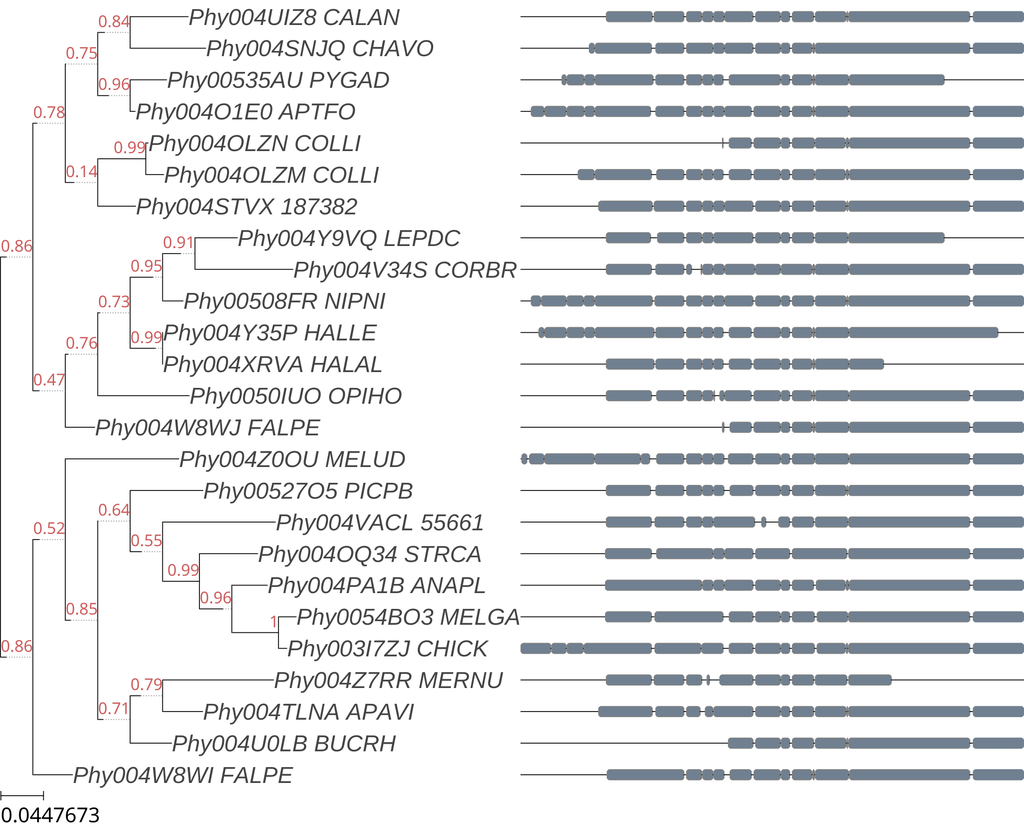

```python
from IPython.display import Image
Image(filename='NUP62_tree/clustalo_default-none-none-fasttree_full/NUP62.aa.fa.final_tree.png')
```

También puedes echar un vistazo rápido al árbol resultante desde tu terminal utilizando el comando `ete3 view --text`.

```python
!ete3 view --text -t NUP62_tree/clustalo_default-none-none-fasttree_full/NUP62.aa.fa.final_tree.nw
```

```
               /-Phy004UIZ8_CALAN
            /-|
           |   \-Phy004SNJQ_CHAVO
         /-|
        |  |   /-Phy00535AU_PYGAD
        |   \-|
      /-|      \-Phy004O1E0_APTFO
     |  |
     |  |      /-Phy004OLZN_COLLI
     |  |   /-|
     |   \-|   \-Phy004OLZM_COLLI
     |     |
     |      \-Phy004STVX_187382
   /-|               /-Phy004Y9VQ_LEPDC
  |  |            /-|
  |  |         /-|   \-Phy004V34S_CORBR
  |  |        |  |
  |  |      /-|   \-Phy00508FR_NIPNI
  |  |     |  |
  |  |     |  |   /-Phy004Y35P_HALLE
  |  |   /-|   \-|
  |  |  |  |      \-Phy004XRVA_HALAL
  |   \-|  |
  |     |   \-Phy0050IUO_OPIHO
  |     |
  |      \-Phy004W8WJ_FALPE
--|
  |      /-Phy004Z0OU_MELUD
  |     |
  |     |      /-Phy00527O5_PICPB
  |     |   /-|
  |   /-|  |  |   /-Phy004VACL_55661
  |  |  |  |   \-|
  |  |  |  |     |   /-Phy004OQ34_STRCA
  |  |  |  |      \-|
  |  |  |  |        |   /-Phy004PA1B_ANAPL
  |  |   \-|         \-|
  |  |     |           |   /-Phy0054BO3_MELGA
  |  |     |            \-|
   \-|     |               \-Phy003I7ZJ_CHICK
     |     |
     |     |      /-Phy004Z7RR_MERNU
     |     |   /-|
     |      \-|   \-Phy004TLNA_APAVI
     |        |
     |         \-Phy004U0LB_BUCRH
      \-Phy004W8WI_FALPE
```

o abrir una interfaz interactiva para explorarlo:

`ete3 view -t NUP62_tree/clustalo_default-none-none-fasttree_full/NUP62.aa.fa.final_tree.nw`

o incluso generar una figura SVG desde la línea de comandos

```python
!ete3 view --image tree.svg -t NUP62_tree/clustalo_default-none-none-fasttree_full/NUP62.aa.fa.final_tree.nw
```

```python
from IPython.display import SVG
SVG(filename='tree.svg')
```

[figure not shown]

# 13. Cargar el árbol y la alineación mediante la API de ete3 para su posterior análisis

Recuerda que la API de Python te permite hacer mucho más, desde establecer el origen, recorrer el árbol o manipular nodos hasta crear visualizaciones personalizadas.

Carga el árbol utilizando el módulo de Python de ete3 y manipúlalo como si fuera un objeto de Python.

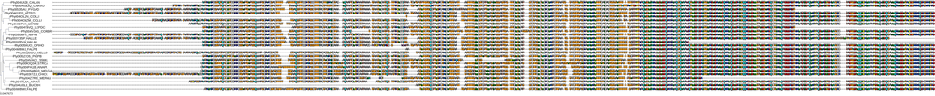

```python
from ete3 import PhyloTree
tree = PhyloTree("NUP62_tree/clustalo_default-none-none-fasttree_full/NUP62.aa.fa.final_tree.nw")
tree.link_to_alignment("NUP62_tree/clustalo_default-none-none-fasttree_full/NUP62.aa.fa.final_tree.used_alg.fa")
tree.render("%%inline")
```

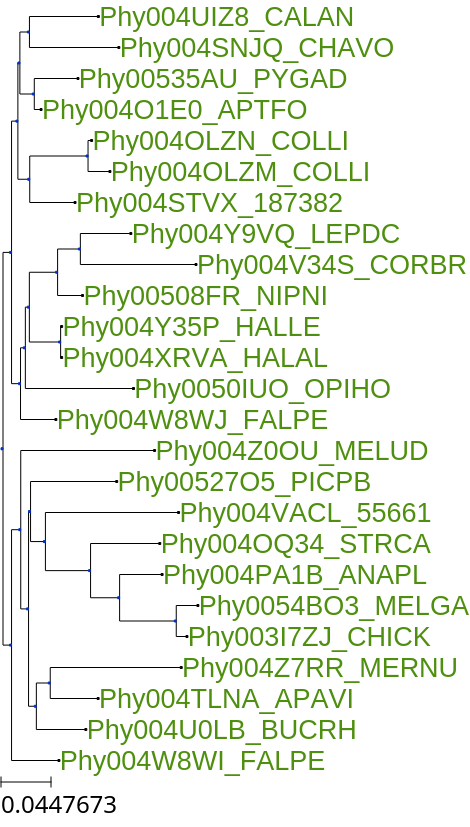

```python
tree.get_common_ancestor("Phy004W8WJ_FALPE", "Phy004OQ34_STRCA").render("%%inline", layout="basic")
```

# Creación de flujos de trabajo personalizados

Esta receta muestra cómo combinar aplicaciones para crear flujos de trabajo personalizados en ete-build. Explica cómo explorar la lista de aplicaciones disponibles y utilizarlas de forma personalizada.

# 1. Explorar las aplicaciones disponibles

Además de la lista de flujos de trabajo predefinidos, ETE permite definir flujos de trabajo personalizados combinando enlaces de aplicaciones predefinidos.

Se puede obtener una lista de las aplicaciones disponibles con el comando ete3 build apps

```python
!ete3 build apps
```

```
----------------------------------------------------------------------------------------------------------
                                                 aligners
----------------------------------------------------------------------------------------------------------
name                 | app type   | desc.
==================== | ========== | ======================================================================
metaligner_phylomedb | metaligner | Meta-aligning based on head/tail alignments produced by muscle, mafft
                     |            | and dialign-tx, scanned with M-Coffee. Unconsistent columns are remove
                     |            | d and final alignment is cleaned with trimAl
-------------------- | ---------- | ----------------------------------------------------------------------
metaligner_trimmed   | metaligner | Meta-aligning based on head/tail alignments produced by muscle, mafft
                     |            | and clustalomega, scanned with M-Coffee. Unconsistent columns are remo
                     |            | ved and final alignment is cleaned with trimAl
-------------------- | ---------- | ----------------------------------------------------------------------
metaligner_default   | metaligner | Meta-aligning based on head/tail alignments produced by muscle, mafft
                     |            | and clustalomega, scanned with M-Coffee. Unconsistent columns are remo
                     |            | ved
-------------------- | ---------- | ----------------------------------------------------------------------
tcoffee_default      | tcoffee    | (EXPERIMENTAL) tcoffee alignment with default paramerters
-------------------- | ---------- | ----------------------------------------------------------------------
mcoffee_ensembl      | tcoffee    | (EXPERIMENTAL) mcoffee alignment as used in the Ensembl database
-------------------- | ---------- | ----------------------------------------------------------------------
muscle_default       | muscle     | muscle alignment with default parameters
-------------------- | ---------- | ----------------------------------------------------------------------
mafft_default        | mafft      | mafft alignment with default parameters
-------------------- | ---------- | ----------------------------------------------------------------------
mafft_einsi          | mafft      | mafft alignment using the E-INS-i mode
-------------------- | ---------- | ----------------------------------------------------------------------
mafft_linsi          | mafft      | mafft alignment using the L-INS-i mode
-------------------- | ---------- | ----------------------------------------------------------------------
mafft_ginsi          | mafft      | mafft alignment using the G-INS-i mode
-------------------- | ---------- | ----------------------------------------------------------------------
clustalo_default     | clustalo   | clustalo with default parameters
==================== | ========== | ======================================================================

---------------------------------------------------------------------------------------------------------------
                                                 model testers
---------------------------------------------------------------------------------------------------------------
name                      | app type   | desc.
========================= | ========== | ======================================================================
prottest_default          | prottest   | Uses BioNJ trees to select best protein model from: JTT, WAG, VT, LG a
```

[output cut: 84 more lines]

```
--------- | ----------- | ------------------------------------------------------------------
cog_95    | cogselector | all COGs including at least 95% of the target species will be used
--------- | ----------- | ------------------------------------------------------------------
cog_90    | cogselector | all COGs including at least 90% of the target species will be used
--------- | ----------- | ------------------------------------------------------------------
cog_85    | cogselector | all COGs including at least 85% of the target species will be used
========= | =========== | ==================================================================

--------------------------------------
          alg concatenators
--------------------------------------
name               | app type  | desc.
================== | ========= | =====
alg_concat_default | concatalg |
================== | ========= | =====
```

Las aplicaciones también se pueden buscar por nombre de grupo: «aligners», «alg cleaners», etc.

```python
!ete3 build apps "model testers" "alg cleaners"
```

```
---------------------------------------------------------------------------------------------------------------
                                                 model testers
---------------------------------------------------------------------------------------------------------------
name                      | app type   | desc.
========================= | ========== | ======================================================================
prottest_default          | prottest   | Uses BioNJ trees to select best protein model from: JTT, WAG, VT, LG a
                          |            | nd MtREV. Fixed parameters: +G+I+F
------------------------- | ---------- | ----------------------------------------------------------------------
pmodeltest_full_ultrafast | pmodeltest | Test all models using NJ tree inference and skipping gamma, invariant
                          |            | sites, and frequency site estimations (!G!I!F)
------------------------- | ---------- | ----------------------------------------------------------------------
pmodeltest_full_fast      | pmodeltest | Test all models using NJ tree inference
------------------------- | ---------- | ----------------------------------------------------------------------
pmodeltest_full_slow      | pmodeltest | Test all models using ML tree inference
------------------------- | ---------- | ----------------------------------------------------------------------
pmodeltest_soft_ultrafast | pmodeltest | Test JTT,WAG,VT,LG,MtREV models using NJ tree inference and skipping g
                          |            | amma, invariant sites, and frequency site estimation (!G!I!F)
------------------------- | ---------- | ----------------------------------------------------------------------
pmodeltest_soft_fast      | pmodeltest | Test JTT,WAG,VT,LG,MtREV models using NJ tree inference
------------------------- | ---------- | ----------------------------------------------------------------------
pmodeltest_soft_slow      | pmodeltest | Test JTT,WAG,VT,LG,MtREV models using ML tree inference
========================= | ========== | ======================================================================

--------------------------------------------------------------------------------------
                                     alg cleaners
--------------------------------------------------------------------------------------
name            | app type | desc.
=============== | ======== | =========================================================
trimal001       | trimal   | trimal alignment cleaning removing columns with >1% gaps
--------------- | -------- | ---------------------------------------------------------
trimal01        | trimal   | trimal alignment cleaning removing columns with >10% gaps
--------------- | -------- | ---------------------------------------------------------
trimal02        | trimal   | trimal alignment cleaning removing columns with >20% gaps
--------------- | -------- | ---------------------------------------------------------
trimal03        | trimal   | trimal alignment cleaning removing columns with >30% gaps
--------------- | -------- | ---------------------------------------------------------
trimal05        | trimal   | trimal alignment cleaning removing columns with >50% gaps
--------------- | -------- | ---------------------------------------------------------
trimal_gappyout | trimal   | trimal alignment cleaning using gappyout algorithm
=============== | ======== | =========================================================
```

# 2. Explicación de los nombres de los flujos de trabajo

Actualmente existen cuatro tipos de aplicaciones que pueden utilizarse para crear un flujo de trabajo: alineadores, recortadores de alineación, comprobadores de modelos y generadores de árboles.

Se puede crear un nombre personalizado para un flujo de trabajo utilizando el siguiente formato:

`aligner-trimmer-tester-builder`

Donde cada palabra, separada por «-», representa un nombre válido de la lista de enlaces de aplicaciones disponibles. Por ejemplo, un nombre de flujo de trabajo válido sería:

`mafft_linsi-trimal01-pmodeltest_soft_ultrafast-raxml_default`

También se permite utilizar la palabra «none» para indicar que un paso debe ignorarse.

# 3. Ejecuta tu flujo de trabajo preferido

Una vez que comprendas cómo funcionan los nombres de los flujos de trabajo, podrás crear tu propia secuencia de programas y ejecutarla mediante ete-build.

```python
!ete3 build -a data/NUP62.aa.fa -o custom/ --clearall -w mafft_linsi-trimal01-pmodeltest_soft_ultrafast-raxml_default
```

```
Toolchain path: /home/alex/miniconda3/envs/ete3/bin/ete3_apps/bin
Toolchain version: unknown
['mafft_linsi-trimal01-pmodeltest_soft_ultrafast-raxml_default']

      --------------------------------------------------------------------------------
                  ETE build (3.1.3) - reproducible phylogenetic workflows

      Citation:

       Huerta-Cepas J, Serra F and Bork P. ETE 3: Reconstruction, analysis and
       visualization of phylogenomic data. Mol Biol Evol (2016)
       doi:10.1093/molbev/msw046

      (Note that a list of the external programs used to complete all necessary
      computations will be shown after workflow execution. Those programs should
      also be cited.)

      --------------------------------------------------------------------------------

INFO -  Testing x86-64  portable applications...
       clustalo: OK - 1.2.4
      dialigntx: OK - This is DIALIGN-TX Version 1.0.2 - A Multiple Sequence alignment program.
       fasttree: OK - Usage for FastTree version 2.1.8 Double precision (No SSE3), OpenMP (1 threads):
         iqtree: OK - IQ-TREE multicore version 1.5.5 for Linux 64-bit built Jun  2 2017
         kalign: OK - Kalign version 2.04, Copyright (C) 2004, 2005, 2006 Timo Lassmann
          mafft: OK - MAFFT v6.861b (2011/09/24)
         muscle: OK - MUSCLE v3.8.31 by Robert C. Edgar
          phyml: OK - . This is PhyML version 20160115.
     pmodeltest: OK - pmodeltest.py v1.4
          raxml: OK - This is RAxML version 8.2.11 released by Alexandros Stamatakis on June 2017.
 raxml-pthreads: OK - This is RAxML version 8.2.11 released by Alexandros Stamatakis on June 2017.
         readal: OK - readAl v1.4.rev6 build[2012-02-02]
         statal: OK - statAl v1.4.rev6 build[2012-02-02]
        tcoffee: OK - PROGRAM: T-COFFEE Version_11.00.8cbe486 (2014-08-12 22:05:29 - Revision 8cbe486 - Build 477)
         trimal: OK - trimAl v1.4.rev6 build[2012-02-02]
INFO -  Starting ETE-build execution at Tue Aug  4 22:20:32 2026
INFO -  Output directory /home/alex/Documentos/topicos-biocumputacion/ete3/custom
INFO -  Erasing all existing npr data...
INFO -  Reading aa sequences from data/NUP62.aa.fa...

```

[output cut: 329 more lines]

```
      automated alignment trimming in large-scale phylogenetic analyses.
      Bioinformatics. 2009 Aug 1;25(15):1972-3.
   Guindon S, Dufayard JF, Lefort V, Anisimova M, Hordijk W, Gascuel O. New
      algorithms and methods to estimate maximum-likelihood phylogenies:
      assessing the performance of PhyML 3.0. Syst Biol. 2010
      May;59(3):307-21.
   Huerta-Cepas J, Serra F, Bork P. ETE 3: Reconstruction, analysis and
      visualization of phylogenomic data. Mol Biol Evol (2016) doi:
      10.1093/molbev/msw046
   Katoh K, Kuma K, Toh H, Miyata T. MAFFT version 5: improvement in
      accuracy of multiple sequence alignment. Nucleic Acids Res. 2005 Jan
      20;33(2):511-8.
   Stamatakis A. RAxML version 8: a tool for phylogenetic analysis and
      post-analysis of large phylogenies Bioinformatics (2014) 30 (9):
      1312-1313.
```

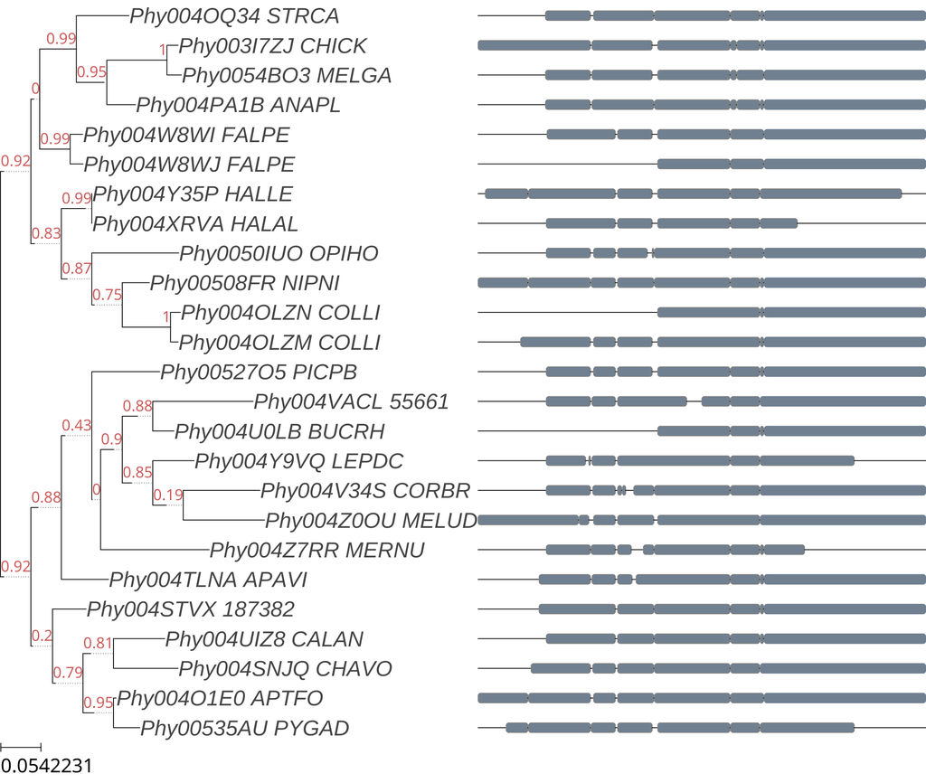

```python
from IPython.display import Image
Image(filename='custom/mafft_linsi-trimal01-pmodeltest_soft_ultrafast-raxml_default//NUP62.aa.fa.final_tree.png')
```

# Uso de ete-build para ejecutar varios flujos de trabajo a la vez

Esta receta muestra cómo aprovechar el potencial de ejecutar varios flujos de trabajo filogenéticos con el mismo conjunto de datos. Se puede utilizar para comprobar los resultados de diferentes alineadores o programas de inferencia.

Los siguientes comandos ilustran esta característica al probar varios alineadores con un único comando.

# 1. Prepara tus secuencias en un archivo FASTA

Utilizaremos un ejemplo sencillo con 25 secuencias. Se recomienda que los encabezados FASTA estén limpios.

```python
!head data/NUP62.aa.fa -n14
```

```
>Phy003I7ZJ_CHICK
TMSQFNFSSAPAGGGFSFSTPKTAASTTAATGFSFTPAPSSGFTFGGAAPTPASSQPVTP
FSFSTPASSALPTAFSFGTPATATTAAPAASVFPLGGNAPKLNFGGTSTTQATGITGGFG
FGTSAPTSVPSSQAAAPSGFMFGTAATTTTTTTAAQPGTTGGFTFSSGTTTQAGTTGFNI
GATSTAAPQAVPTGLTFGAAPAAAATTTASLGSTTQPAATPFSLGGQSSATLTASTSQGP
TLSFGSKLGVTTTASTTTAASTAPLLGSTGPVLFASIASSSAPASSTSTGLSLGAPSTGT
TGLGTSGFGLKPPGTTAAATSTATSTSASSFALNLKPLTTTGTIGAVTSTAAITTTTPSA
PPVMTYAQLESLINKWSLELEDQEKHFLHQATQVNAWDRTLIENGEKITSLHREVEKVKL
DQKRLDQELDFILSQQKELEDLLTPLEESVKEQSGTIYLQHADEERERTYKLAENIDAQL
KRMAQDLKDIIEHLNTSGRPADTSDPLQQICKILNAHMDSLQWIDQNSALLQRKVEEVTK
VCESRRKEQERSFRITFD
>Phy0054BO3_MELGA
GNAPKLNFGGTSTTQATGITGGFGFGTSAPTSVPSSQAAAPSGFMFGSATATTTTTTAAQ
PGTTGGFTFSSGTTTQAGTTGFNIGTTSTAAPQAAPTGLTFGAAPAAAAATTTASLGSTA
```

# 2. Consulta los alineadores disponibles en ete3

```python
!ete3 build apps aligners
```

```
----------------------------------------------------------------------------------------------------------
                                                 aligners
----------------------------------------------------------------------------------------------------------
name                 | app type   | desc.
==================== | ========== | ======================================================================
metaligner_phylomedb | metaligner | Meta-aligning based on head/tail alignments produced by muscle, mafft
                     |            | and dialign-tx, scanned with M-Coffee. Unconsistent columns are remove
                     |            | d and final alignment is cleaned with trimAl
-------------------- | ---------- | ----------------------------------------------------------------------
metaligner_trimmed   | metaligner | Meta-aligning based on head/tail alignments produced by muscle, mafft
                     |            | and clustalomega, scanned with M-Coffee. Unconsistent columns are remo
                     |            | ved and final alignment is cleaned with trimAl
-------------------- | ---------- | ----------------------------------------------------------------------
metaligner_default   | metaligner | Meta-aligning based on head/tail alignments produced by muscle, mafft
                     |            | and clustalomega, scanned with M-Coffee. Unconsistent columns are remo
                     |            | ved
-------------------- | ---------- | ----------------------------------------------------------------------
tcoffee_default      | tcoffee    | (EXPERIMENTAL) tcoffee alignment with default paramerters
-------------------- | ---------- | ----------------------------------------------------------------------
mcoffee_ensembl      | tcoffee    | (EXPERIMENTAL) mcoffee alignment as used in the Ensembl database
-------------------- | ---------- | ----------------------------------------------------------------------
muscle_default       | muscle     | muscle alignment with default parameters
-------------------- | ---------- | ----------------------------------------------------------------------
mafft_default        | mafft      | mafft alignment with default parameters
-------------------- | ---------- | ----------------------------------------------------------------------
mafft_einsi          | mafft      | mafft alignment using the E-INS-i mode
-------------------- | ---------- | ----------------------------------------------------------------------
mafft_linsi          | mafft      | mafft alignment using the L-INS-i mode
-------------------- | ---------- | ----------------------------------------------------------------------
mafft_ginsi          | mafft      | mafft alignment using the G-INS-i mode
-------------------- | ---------- | ----------------------------------------------------------------------
clustalo_default     | clustalo   | clustalo with default parameters
==================== | ========== | ======================================================================
```

# 3. Introduce los nombres de los flujos de trabajo de destino

Puedes hacerlo manualmente o mediante un script de Bash.

```python
%%bash
for aligner in mafft_einsi mafft_linsi mafft_ginsi clustalo_default;
    do echo $aligner-none-none-fasttree_default;
done;
```

```
mafft_einsi-none-none-fasttree_default
mafft_linsi-none-none-fasttree_default
mafft_ginsi-none-none-fasttree_default
clustalo_default-none-none-fasttree_default
```

# 4. Ejecutar todos los flujos de trabajo a la vez

```python
%%bash
ete3 build -a data/NUP62.aa.fa -o test_aligners --clearall -w mafft_einsi-none-none-fasttree_default \
    mafft_linsi-none-none-fasttree_default \
    mafft_ginsi-none-none-fasttree_default \
    clustalo_default-none-none-fasttree_default;
```

```
Toolchain path: /home/alex/miniconda3/envs/ete3/bin/ete3_apps/bin
Toolchain version: unknown
['mafft_einsi-none-none-fasttree_default']
['mafft_linsi-none-none-fasttree_default']
['mafft_ginsi-none-none-fasttree_default']
['clustalo_default-none-none-fasttree_default']

      --------------------------------------------------------------------------------
                  ETE build (3.1.3) - reproducible phylogenetic workflows

      Citation:

       Huerta-Cepas J, Serra F and Bork P. ETE 3: Reconstruction, analysis and
       visualization of phylogenomic data. Mol Biol Evol (2016)
       doi:10.1093/molbev/msw046

      (Note that a list of the external programs used to complete all necessary
      computations will be shown after workflow execution. Those programs should
      also be cited.)

      --------------------------------------------------------------------------------

INFO -  Testing x86-64  portable applications...
       clustalo: OK - 1.2.4
      dialigntx: OK - This is DIALIGN-TX Version 1.0.2 - A Multiple Sequence alignment program.
       fasttree: OK - FastTree Version 2.1.8 Double precision (No SSE3), OpenMP (1 threads)
         iqtree: OK - IQ-TREE multicore version 1.5.5 for Linux 64-bit built Jun  2 2017
         kalign: OK - Kalign version 2.04, Copyright (C) 2004, 2005, 2006 Timo Lassmann
          mafft: OK - MAFFT v6.861b (2011/09/24)
         muscle: OK - MUSCLE v3.8.31 by Robert C. Edgar
          phyml: OK - . This is PhyML version 20160115.
     pmodeltest: OK - pmodeltest.py v1.4
          raxml: OK - This is RAxML version 8.2.11 released by Alexandros Stamatakis on June 2017.
 raxml-pthreads: OK - This is RAxML version 8.2.11 released by Alexandros Stamatakis on June 2017.
         readal: OK - readAl v1.4.rev6 build[2012-02-02]
         statal: OK - statAl v1.4.rev6 build[2012-02-02]
        tcoffee: OK - PROGRAM: T-COFFEE Version_11.00.8cbe486 (2014-08-12 22:05:29 - Revision 8cbe486 - Build 477)
         trimal: OK - trimAl v1.4.rev6 build[2012-02-02]
INFO -  Starting ETE-build execution at Tue Aug  4 22:24:56 2026
INFO -  Output directory /home/alex/Documentos/topicos-biocumputacion/ete3/test_aligners
```

[output cut: 216 more lines]

```
   ========================================================================
   Sievers F, Wilm A, Dineen D, Gibson TJ, Karplus K, Li W, Lopez R,
      McWilliam H, Remmert M, Söding J, Thompson JD, Higgins DG. Fast,
      scalable generation of high-quality protein multiple sequence
      alignments using Clustal Omega. Mol Syst Biol. 2011 Oct 11;7:539.
      doi: 10.1038/msb.2011.75.
   Huerta-Cepas J, Serra F, Bork P. ETE 3: Reconstruction, analysis and
      visualization of phylogenomic data. Mol Biol Evol (2016) doi:
      10.1093/molbev/msw046
   Katoh K, Kuma K, Toh H, Miyata T. MAFFT version 5: improvement in
      accuracy of multiple sequence alignment. Nucleic Acids Res. 2005 Jan
      20;33(2):511-8.
   Price MN, Dehal PS, Arkin AP. FastTree 2 - approximately maximum-
      likelihood trees for large alignments. PLoS One. 2010 Mar
      10;5(3):e9490.
```

Al cabo de unos segundos, deberías tener cuatro subcarpetas en el directorio «test_aligners/».

```python
!find test_aligners/ -name '*.final_tree.nw'
```

```
test_aligners/mafft_einsi-none-none-fasttree_default/NUP62.aa.fa.final_tree.nw
test_aligners/clustalo_default-none-none-fasttree_default/NUP62.aa.fa.final_tree.nw
test_aligners/mafft_ginsi-none-none-fasttree_default/NUP62.aa.fa.final_tree.nw
test_aligners/mafft_linsi-none-none-fasttree_default/NUP62.aa.fa.final_tree.nw
```

Comparemos el árbol basado en ClustalOmega con el resto de árboles basados en MAFFT.

```python
%%bash
ete3 compare -r test_aligners/clustalo_default-none-none-fasttree_default/NUP62.aa.fa.final_tree.nw \
    -t `find test_aligners/ -name '*.final_tree.nw'` --unrooted
```

```
source          | ref             | E.size  | nRF     | RF      | maxRF   | src-br+ | ref-br+ | subtre+ | treekoD
==============+ | ==============+ | ======+ | ======+ | ======+ | ======+ | ======+ | ======+ | ======+ | ======+
(..)_einsi-non+ | (..)alo_defaul+ | 25      | 0.41    | 18.00   | 44.00   | 0.80    | 0.80    | 1       | NA
(..)alo_defaul+ | (..)alo_defaul+ | 25      | 0.00    | 0.00    | 44.00   | 1.00    | 1.00    | 1       | NA
(..)_ginsi-non+ | (..)alo_defaul+ | 25      | 0.41    | 18.00   | 44.00   | 0.80    | 0.80    | 1       | NA
(..)_linsi-non+ | (..)alo_defaul+ | 25      | 0.41    | 18.00   | 44.00   | 0.80    | 0.80    | 1       | NA
```

Echemos un vistazo a dónde se encuentran esas diferencias en la topología del árbol y en la alineación.

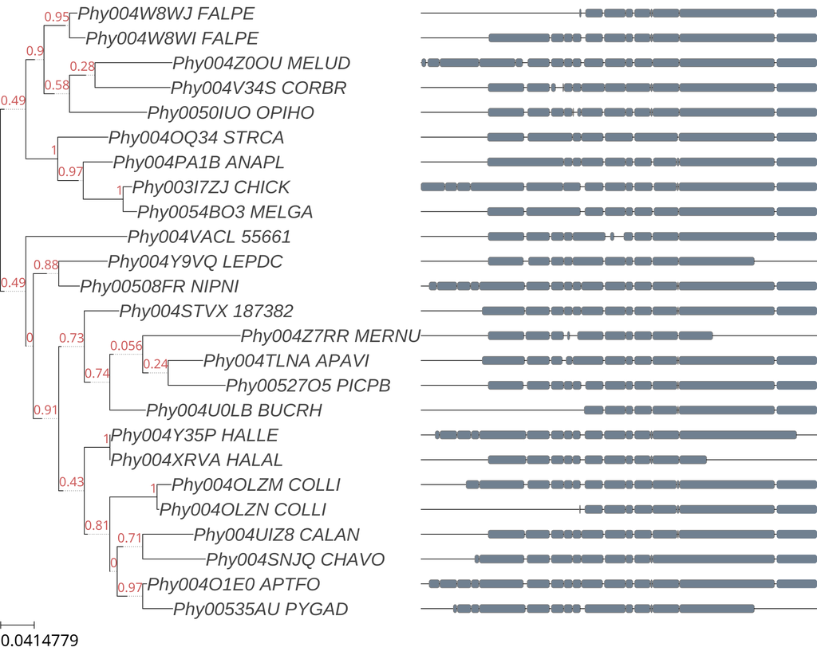

```python
from IPython.display import Image
Image(filename='test_aligners/clustalo_default-none-none-fasttree_default/NUP62.aa.fa.final_tree.png')
```

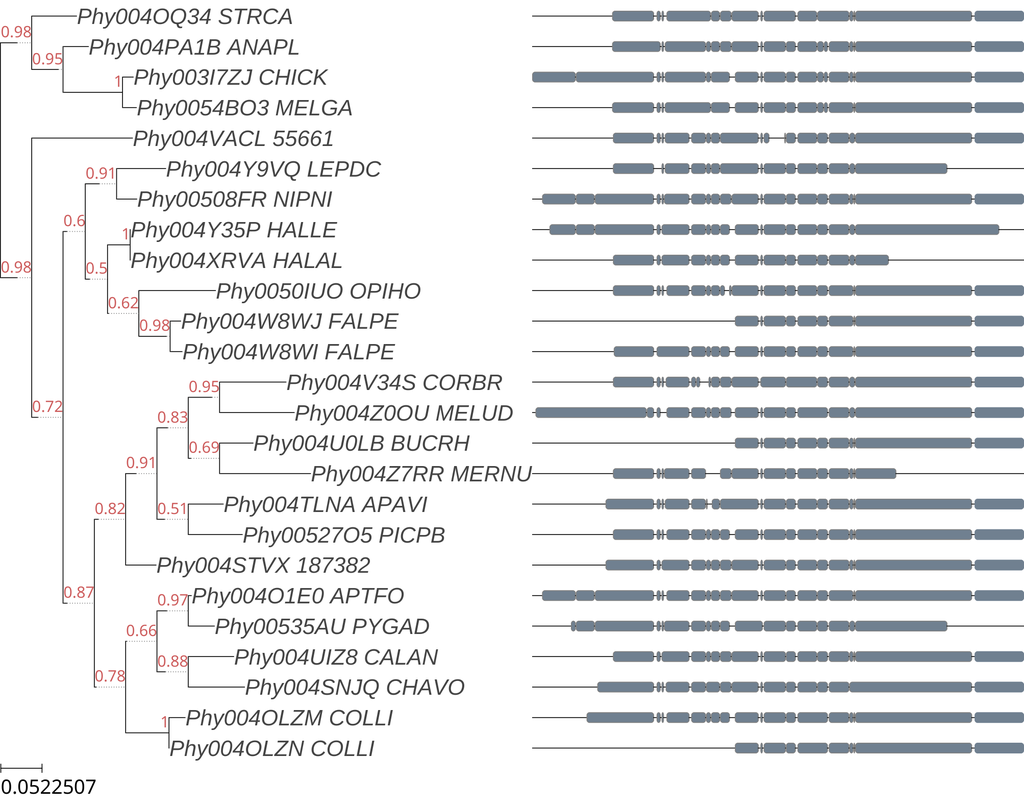

```python
Image(filename='test_aligners/mafft_linsi-none-none-fasttree_default/NUP62.aa.fa.final_tree.png')
```

# Creación de nuevos flujos de trabajo y enlaces a aplicaciones

Se muestra cómo crear nuevos enlaces a aplicaciones para generar nuevos flujos de trabajo.

ete-build incluye varias aplicaciones preconfiguradas, diseñadas para cubrir las opciones predeterminadas del software compatible y algunos enfoques habituales. Aquí aprenderás a crear configuraciones personalizadas que podrás utilizar en los flujos de trabajo.

# 1. Configuración de llamadas a software externo

Al crear flujos de trabajo personalizados, has aprendido a hacer referencia a las diferentes opciones preconfiguradas en ete-build.

Puedes explorar los detalles de cualquier enlace de aplicación (o incluso de un flujo de trabajo) utilizando el comando ete3 build show [nombre del bloque].

```python
%%bash
ete3 build show raxml_default
ete3 build show phyml_default
ete3 build show mafft_linsi
```

```
[raxml_default]
                                 -f = d
                                 -p = 31416
                          _aa_model = JTT
                               _app = raxml
                         _bootstrap = alrt
                              _desc = RAxML with default parameters, GAMMA JTT/GTR and aLRT branch supports.
                            _method = GAMMA
                      _model_suffix =

[phyml_default]
                            --alpha = e
                        --bootstrap = -2
                         --nclasses = 4
                             --pinv = e
                                 -f = m
                                 -o = tlr
                          _aa_model = JTT
                               _app = phyml
                              _desc = Phyml tree using +G+I+F, 4 classes and aLRT branch supports. Default models JTT/GTR
                          _nt_model = GTR

[mafft_linsi]
                        --localpair =
                       --maxiterate = 1000
                               _app = mafft
                              _desc = mafft alignment using the L-INS-i mode
```

Como probablemente habrá notado, cada enlace de aplicación al que se hace referencia en los nombres de los flujos de trabajo se define como un bloque de configuración cuyo nombre aparece entre corchetes. Para crear nuevos bloques de configuración, debe tener en cuenta los siguientes conceptos:

- El nombre del bloque no debe contener otros símbolos que no sean texto, números y guiones bajos. Nunca utilice guiones.
- Cada bloque se compone de varias ete-buildopciones internas y varias opciones de software nativas.
- Las opciones internas siempre van precedidas de un guion bajo y se utilizan para definir el software que se va a ejecutar, la descripción del bloque de configuración y algunos parámetros predeterminados que no deben codificarse como argumentos nativos del programa.
- Cualquier otra opción en el formato "argumento = valor" se considera una opción nativa y se pasa tal cual al software correspondiente.
- Para pasar indicadores como argumentos, puede usar la sintaxis " argument = ''" o simplemente " argument ="

# 2. Creación de nuevos bloques de configuración

Imaginemos que queremos crear un nuevo flujo de trabajo donde RAxML deba configurarse de una manera diferente.

Lo único que tenemos que hacer es volcar cualquier bloque de configuración basado en los enlaces RAxML de los ejemplos proporcionados y modificarlo. Puedes volcar los bloques de configuración como texto normal con el ete2 build dumpcomando:

```python
%%bash
ete3 build dump raxml_default > myconfig.cfg
cat myconfig.cfg
```

```
[raxml_default]
                                      -f = d
                                      -p = 31416
                               _aa_model = JTT
                                    _app = raxml
                              _bootstrap = alrt
                                   _desc = RAxML with default parameters, GAMMA JTT/GTR and aLRT branch supports.
                                 _method = GAMMA
                           _model_suffix =
```

```python
%%bash
echo '
[raxml_CAT_10]
                         _desc = RAxML with default parameters, CAT with 100 bootstraps.
                          _app = raxml
                    _bootstrap = 10
                       _method = CAT
                     _aa_model = JTT
                 _model_suffix =
                            -f = d
                            -p = 31416
' > myconfig.cfg
cat myconfig.cfg
```

```
[raxml_CAT_10]
                         _desc = RAxML with default parameters, CAT with 100 bootstraps.
                          _app = raxml
                    _bootstrap = 10
                       _method = CAT
                     _aa_model = JTT
                 _model_suffix =
                            -f = d
                            -p = 31416
```

Ahora vamos a modificar las opciones, de modo que el bloque de configuración quede así (10 bootstraps y modelo CAT):

# 3. Uso de bloques de configuración personalizados

Una vez que haya creado todos sus bloques de configuración personal, puede utilizarlos para ejecutar flujos de trabajo personalizados pasando su archivo de configuración con la '-c'opción de ete-build

Tenga en cuenta que, en este ejemplo, también estamos habilitando 4 CPU; puede ajustar este parámetro a su sistema.

```python
%%bash
ete3 build -a data/NUP62.aa.fa --clearall -o raxml_cat/ -w mafft_linsi-none-none-raxml_CAT_10 -c myconfig.cfg --cpu 4
```

```
Toolchain path: /home/alex/miniconda3/envs/ete3/bin/ete3_apps/bin
Toolchain version: unknown
['mafft_linsi-none-none-raxml_CAT_10']

      --------------------------------------------------------------------------------
                  ETE build (3.1.3) - reproducible phylogenetic workflows

      Citation:

       Huerta-Cepas J, Serra F and Bork P. ETE 3: Reconstruction, analysis and
       visualization of phylogenomic data. Mol Biol Evol (2016)
       doi:10.1093/molbev/msw046

      (Note that a list of the external programs used to complete all necessary
      computations will be shown after workflow execution. Those programs should
      also be cited.)

      --------------------------------------------------------------------------------

INFO -  Testing x86-64  portable applications...
       clustalo: OK - 1.2.4
      dialigntx: OK - This is DIALIGN-TX Version 1.0.2 - A Multiple Sequence alignment program.
       fasttree: OK - FastTree Version 2.1.8 Double precision (No SSE3), OpenMP (2 threads)
         iqtree: OK - IQ-TREE multicore version 1.5.5 for Linux 64-bit built Jun  2 2017
         kalign: OK - Kalign version 2.04, Copyright (C) 2004, 2005, 2006 Timo Lassmann
          mafft: OK - MAFFT v6.861b (2011/09/24)
         muscle: OK - MUSCLE v3.8.31 by Robert C. Edgar
          phyml: OK - . This is PhyML version 20160115.
     pmodeltest: OK - pmodeltest.py v1.4
          raxml: OK - This is RAxML version 8.2.11 released by Alexandros Stamatakis on June 2017.
 raxml-pthreads: OK - This is RAxML version 8.2.11 released by Alexandros Stamatakis on June 2017.
         readal: OK - readAl v1.4.rev6 build[2012-02-02]
         statal: OK - statAl v1.4.rev6 build[2012-02-02]
        tcoffee: OK - PROGRAM: T-COFFEE Version_11.00.8cbe486 (2014-08-12 22:05:29 - Revision 8cbe486 - Build 477)
         trimal: OK - trimAl v1.4.rev6 build[2012-02-02]
INFO -  Starting ETE-build execution at Tue Aug  4 22:29:08 2026
INFO -  Output directory /home/alex/Documentos/topicos-biocumputacion/ete3/raxml_cat
INFO -  Erasing all existing npr data...
INFO -  Reading aa sequences from data/NUP62.aa.fa...

```

[output cut: 1105 more lines]

```
INFO -  Done
INFO -  Deleting temporal data...
   ========================================================================
         The following published software and/or methods were used.
               *** Please, do not forget to cite them! ***
   ========================================================================
   Huerta-Cepas J, Serra F, Bork P. ETE 3: Reconstruction, analysis and
      visualization of phylogenomic data. Mol Biol Evol (2016) doi:
      10.1093/molbev/msw046
   Katoh K, Kuma K, Toh H, Miyata T. MAFFT version 5: improvement in
      accuracy of multiple sequence alignment. Nucleic Acids Res. 2005 Jan
      20;33(2):511-8.
   Stamatakis A. RAxML version 8: a tool for phylogenetic analysis and
      post-analysis of large phylogenies Bioinformatics (2014) 30 (9):
      1312-1313.
```

Tras unos minutos, debería estar listo un árbol basado en 10 réplicas de bootstrap RAxML utilizando CAT. Ahora puede cargar y analizar el árbol.

```python
from ete3 import Tree
cat_tree = Tree("raxml_cat/mafft_linsi-none-none-raxml_CAT_10/NUP62.aa.fa.final_tree.nw")
print(cat_tree.get_ascii(attributes=["support", "name"]))
```

```
          /-1.0, Phy004OQ34_STRCA
     /1.0,
    |    |     /-1.0, Phy004PA1B_ANAPL
    |     \1.0,
    |         |     /-1.0, Phy0054BO3_MELGA
    |          \1.0,
    |               \-1.0, Phy003I7ZJ_CHICK
    |               /-1.0, Phy0050IUO_OPIHO
    |          /0.0,
-1.0,         |    |     /-1.0, Phy004Y35P_HALLE
    |         |     \1.0,
    |     /0.0,          \-1.0, Phy004XRVA_HALAL
    |    |    |
    |    |    |     /-1.0, Phy004W8WJ_FALPE
    |    |     \0.7,
    |    |          \-1.0, Phy004W8WI_FALPE
    |    |
    |    |          /-1.0, Phy00508FR_NIPNI
    |    |         |
     \1.0,     /0.0,     /-1.0, Phy004VACL_55661
         |    |    |    |
         |    |     \0.0,          /-1.0, Phy004V34S_CORBR
         |    |         |     /0.3,
         |    |         |    |     \-1.0, Phy004Y9VQ_LEPDC
         |    |          \0.3,
         |    |              |     /-1.0, Phy004OLZM_COLLI
         |    |               \0.9,
          \0.1,                    \-1.0, Phy004OLZN_COLLI
              |               /-1.0, Phy004SNJQ_CHAVO
              |          /0.8,
              |         |     \-1.0, Phy004UIZ8_CALAN
              |     /0.5,
              |    |    |     /-1.0, Phy004O1E0_APTFO
              |    |     \0.9,
               \0.0,          \-1.0, Phy00535AU_PYGAD
                   |     /-1.0, Phy004STVX_187382
                   |    |
                    \0.0,          /-1.0, Phy004Z7RR_MERNU
                        |     /0.1,
                        |    |     \-1.0, Phy004U0LB_BUCRH
                         \0.0,
                             |     /-1.0, Phy004TLNA_APAVI
                              \0.0,
                                  |     /-1.0, Phy00527O5_PICPB
                                   \0.4,
                                        \-1.0, Phy004Z0OU_MELUD
```

# Cambio automático de alineamientos basados en aminoácidos a alineamientos basadas en codones

Se muestra cómo utilizar ete-build para construir árboles filogenéticos de genes basados en nucleótidos a partir de alineaciones de aminoácidos.

Por ejemplo, si la identidad media de las secuencias en la alineación de aminoácidos es superior a un umbral determinado, ete-build traducirá automáticamente la alineación de aminoácidos a una alineación basada en codones e inferirá un árbol a partir de los modelos de nucleótidos (no se admiten modelos de codones).

Este es un enfoque útil cuando las alineaciones de proteínas no proporcionan suficiente resolución filogenética (es decir, las mutaciones sinónimas quedan enmascaradas), pero se desea seguir utilizando alineaciones basadas en aminoácidos para obtener una mayor precisión frente a las basadas en nucleótidos.

# 1. Preparar archivos FASTA con secuencias múltiples de aminoácidos y nucleótidos

Ambos archivos FASTA deben contener exactamente el mismo conjunto de nombres de secuencias. Las secuencias de nucleótidos deben corresponder a la secuencia codificante de las secuencias de aminoácidos (es decir, deben tener la misma longitud).

```python
%%bash
head data/NUP62.aa.fa data/NUP62.nt.fa -n5
```

```
==> data/NUP62.aa.fa <==
>Phy003I7ZJ_CHICK
TMSQFNFSSAPAGGGFSFSTPKTAASTTAATGFSFTPAPSSGFTFGGAAPTPASSQPVTP
FSFSTPASSALPTAFSFGTPATATTAAPAASVFPLGGNAPKLNFGGTSTTQATGITGGFG
FGTSAPTSVPSSQAAAPSGFMFGTAATTTTTTTAAQPGTTGGFTFSSGTTTQAGTTGFNI
GATSTAAPQAVPTGLTFGAAPAAAATTTASLGSTTQPAATPFSLGGQSSATLTASTSQGP

==> data/NUP62.nt.fa <==
>Phy003I7ZJ_CHICK
ACCATGAGCCAGTTCAACTTCAGCTCGGCCCCGGCGGGAGGCGGCTTCTCCTTCAGCACGCCGAAAACGGCCGCCAGCAC
CACCGCGGCCACCGGCTTCTCCTTCACGCCCGCTCCCTCCTCGGGATTCACGTTCGGCGGCGCTGCTCCGACACCCGCCA
GCAGCCAGCCCGTCACGCCCTTCTCCTTCAGCACGCCGGCCAGCAGCGCGCTGCCCACCGCCTTCAGCTTCGGGACGCCC
GCAACAGCCACCACCGCCGCCCCGGCTGCCAGCGTGTTCCCGTTAGGGGGAAACGCACCAAAGCTCAACTTTGGAGGCAC
```

# 2. Activar el modo mixto en los flujos de trabajo de ete-build

Para ello, pasa ambos archivos FASTA como argumentos a ete-build (-a para proteínas, -n para secuencias de nucleótidos) especificando un umbral para el cambio de aa a nt. Es decir, la identidad máxima permitida en la secuencia de proteínas para construir árboles basados en proteínas. Si la identidad media de las secuencias en una alineación de proteínas es superior al umbral establecido, ete-build convertirá la alineación en una alineación basada en codones y continuará inferiendo el árbol utilizando un modelo de nucleótidos.

En el siguiente ejemplo, configuramos el flujo de trabajo para que utilice alineaciones de nucleótidos si la similitud media de las proteínas es superior al 90 %.

```python
%%bash
ete3 build -a data/NUP62.aa.fa -n data/NUP62.nt.fa -o mixed_types/ -w standard_fasttree --clearall --nt-switch-threshold 0.9
```

```
Toolchain path: /home/alex/miniconda3/envs/ete3/bin/ete3_apps/bin
Toolchain version: unknown
['clustalo_default-none-none-fasttree_full']

      --------------------------------------------------------------------------------
                  ETE build (3.1.3) - reproducible phylogenetic workflows

      Citation:

       Huerta-Cepas J, Serra F and Bork P. ETE 3: Reconstruction, analysis and
       visualization of phylogenomic data. Mol Biol Evol (2016)
       doi:10.1093/molbev/msw046

      (Note that a list of the external programs used to complete all necessary
      computations will be shown after workflow execution. Those programs should
      also be cited.)

      --------------------------------------------------------------------------------

INFO -  Testing x86-64  portable applications...
       clustalo: OK - 1.2.4
      dialigntx: OK - This is DIALIGN-TX Version 1.0.2 - A Multiple Sequence alignment program.
       fasttree: OK - FastTree Version 2.1.8 Double precision (No SSE3), OpenMP (1 threads)
         iqtree: OK - IQ-TREE multicore version 1.5.5 for Linux 64-bit built Jun  2 2017
         kalign: OK - Kalign version 2.04, Copyright (C) 2004, 2005, 2006 Timo Lassmann
          mafft: OK - MAFFT v6.861b (2011/09/24)
         muscle: OK - MUSCLE v3.8.31 by Robert C. Edgar
          phyml: OK - . This is PhyML version 20160115.
     pmodeltest: OK - pmodeltest.py v1.4
          raxml: OK - This is RAxML version 8.2.11 released by Alexandros Stamatakis on June 2017.
 raxml-pthreads: OK - This is RAxML version 8.2.11 released by Alexandros Stamatakis on June 2017.
         readal: OK - readAl v1.4.rev6 build[2012-02-02]
         statal: OK - statAl v1.4.rev6 build[2012-02-02]
        tcoffee: OK - PROGRAM: T-COFFEE Version_11.00.8cbe486 (2014-08-12 22:05:29 - Revision 8cbe486 - Build 477)
         trimal: OK - trimAl v1.4.rev6 build[2012-02-02]
INFO -  Starting ETE-build execution at Tue Aug  4 22:44:20 2026
INFO -  Output directory /home/alex/Documentos/topicos-biocumputacion/ete3/mixed_types
INFO -  Erasing all existing npr data...
INFO -  Reading aa sequences from data/NUP62.aa.fa...

```

[output cut: 86 more lines]

```
   ========================================================================
         The following published software and/or methods were used.
               *** Please, do not forget to cite them! ***
   ========================================================================
   Sievers F, Wilm A, Dineen D, Gibson TJ, Karplus K, Li W, Lopez R,
      McWilliam H, Remmert M, Söding J, Thompson JD, Higgins DG. Fast,
      scalable generation of high-quality protein multiple sequence
      alignments using Clustal Omega. Mol Syst Biol. 2011 Oct 11;7:539.
      doi: 10.1038/msb.2011.75.
   Huerta-Cepas J, Serra F, Bork P. ETE 3: Reconstruction, analysis and
      visualization of phylogenomic data. Mol Biol Evol (2016) doi:
      10.1093/molbev/msw046
   Price MN, Dehal PS, Arkin AP. FastTree 2 - approximately maximum-
      likelihood trees for large alignments. PLoS One. 2010 Mar
      10;5(3):e9490.
```

Durante la ejecución, apareció una advertencia como esta:

¡Cambiando a la alineación de codones! Similitud de la secuencia de aminoácidos: 0,91 >= 0,90

En la carpeta de resultados se incluirán tanto las alineaciones de aminoácidos como las de nucleótidos. La alineación basada en codones se denomina «*.used_alg.fa», ya que es la alineación que se ha utilizado realmente para construir el árbol resultante.

```python
%%bash
head -n2 mixed_types/clustalo_default-none-none-fasttree_full/NUP62.aa.fa.final_tree.fa
```

```
>Phy004STVX_187382
-------------------------------------------------------------------------------------------AANVFPLGANAAKLNFGGSTATQAAGIAGGFGFGSSVPTSVPSSQAAAPSGFVFGSAGTTTSTT--TTAAAQSGTTGGFTFSSGTTTQAGTASFNISTAA---PQAAPTGLTFGTAPAAA-ATTAATVGAATQS-MTPFSLGGQSAA-TSAPTATLTTGTTQGPALSFGTKLGAATTAAS---TTATTTTSILGSTGPTLFASIVSSSA…
```

```python
%%bash
head -n2 mixed_types/clustalo_default-none-none-fasttree_full/NUP62.aa.fa.final_tree.used_alg.fa
```

```
>Phy004STVX_187382
---------------------------------------------------------------------------------------------------------------------------------------------------------------------------------------------------------------------------------------------------------------------------------GCAGCAAACGTGTTCCCGCTGGGGGCA…
```

# Uso de alineamientos manuales

Esta guía muestra cómo ejecutar un flujo de trabajo filogenético omitiendo la fase de alineación de secuencias. Esto permite tratar las secuencias de entrada como si estuvieran alineadas y utilizarlas tal cual en los pasos siguientes.

El único paso necesario para utilizar alineaciones manuales es establecer en «ninguna» la tarea de alineación en el nombre de tu flujo de trabajo preferido.

Por ejemplo, la siguiente ejecución llevará a cabo una prueba de modelo y generará un árbol con raxml a partir de un conjunto de secuencias prealineadas:

```python
%%bash
ete3 build -a data/P53.alg.fa -w none-none-pmodeltest_soft_ultrafast-raxml_default -o manual_alg --clearall
```

```
Toolchain path: /home/alex/miniconda3/envs/ete3/bin/ete3_apps/bin
Toolchain version: unknown
['none-none-pmodeltest_soft_ultrafast-raxml_default']

      --------------------------------------------------------------------------------
                  ETE build (3.1.3) - reproducible phylogenetic workflows

      Citation:

       Huerta-Cepas J, Serra F and Bork P. ETE 3: Reconstruction, analysis and
       visualization of phylogenomic data. Mol Biol Evol (2016)
       doi:10.1093/molbev/msw046

      (Note that a list of the external programs used to complete all necessary
      computations will be shown after workflow execution. Those programs should
      also be cited.)

      --------------------------------------------------------------------------------

INFO -  Testing x86-64  portable applications...
       clustalo: OK - 1.2.4
      dialigntx: OK - This is DIALIGN-TX Version 1.0.2 - A Multiple Sequence alignment program.
       fasttree: OK - FastTree Version 2.1.8 Double precision (No SSE3), OpenMP (1 threads)
         iqtree: OK - IQ-TREE multicore version 1.5.5 for Linux 64-bit built Jun  2 2017
         kalign: OK - Kalign version 2.04, Copyright (C) 2004, 2005, 2006 Timo Lassmann
          mafft: OK - MAFFT v6.861b (2011/09/24)
         muscle: OK - MUSCLE v3.8.31 by Robert C. Edgar
          phyml: OK - . This is PhyML version 20160115.
     pmodeltest: OK - pmodeltest.py v1.4
          raxml: OK - This is RAxML version 8.2.11 released by Alexandros Stamatakis on June 2017.
 raxml-pthreads: OK - This is RAxML version 8.2.11 released by Alexandros Stamatakis on June 2017.
         readal: OK - readAl v1.4.rev6 build[2012-02-02]
         statal: OK - statAl v1.4.rev6 build[2012-02-02]
        tcoffee: OK - PROGRAM: T-COFFEE Version_11.00.8cbe486 (2014-08-12 22:05:29 - Revision 8cbe486 - Build 477)
         trimal: OK - trimAl v1.4.rev6 build[2012-02-02]
INFO -  Starting ETE-build execution at Tue Aug  4 22:47:39 2026
INFO -  Output directory /home/alex/Documentos/topicos-biocumputacion/ete3/manual_alg
INFO -  Erasing all existing npr data...
INFO -  Reading aa sequences from data/P53.alg.fa...

```

[output cut: 83 more lines]

```
INFO -  Deleting temporal data...
   ========================================================================
         The following published software and/or methods were used.
               *** Please, do not forget to cite them! ***
   ========================================================================
   Guindon S, Dufayard JF, Lefort V, Anisimova M, Hordijk W, Gascuel O. New
      algorithms and methods to estimate maximum-likelihood phylogenies:
      assessing the performance of PhyML 3.0. Syst Biol. 2010
      May;59(3):307-21.
   Huerta-Cepas J, Serra F, Bork P. ETE 3: Reconstruction, analysis and
      visualization of phylogenomic data. Mol Biol Evol (2016) doi:
      10.1093/molbev/msw046
   Stamatakis A. RAxML version 8: a tool for phylogenetic analysis and
      post-analysis of large phylogenies Bioinformatics (2014) 30 (9):
      1312-1313.
```

# Comprobación de hipótesis evolutivas (ete-evol)

**Reproducir el análisis CODEML de Yang Z (MBE, 1998)**

Se muestra cómo reproducir el análisis realizado en Yang Z (MBE, 1998) utilizando ete-evol. Los archivos de datos se han extraído de los ejemplos del paquete PAML; se utilizará un conjunto de datos pequeño:

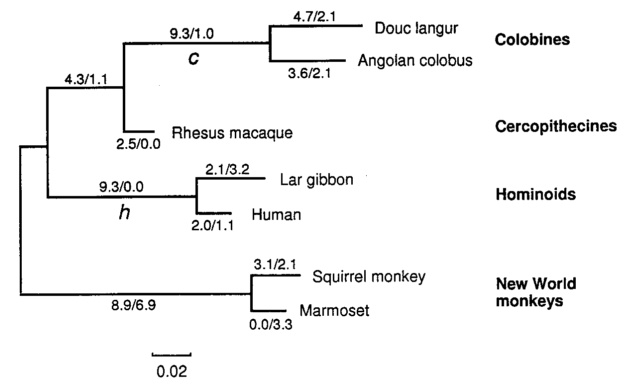

```python
from IPython.display import Image
Image(filename='data/lysozyme/Lysozyme_small_tree.png')
```

Los archivos que vamos a utilizar para este ejemplo son:

data/lysozyme/lysozymeSmall.txt  
data/lysozyme/lysozymeSmall.trees  
data/lysozyme/lysozymeSmall.ctl

**Modelos de ramificación**

Ahora vamos a intentar reproducir los resultados del artículo correspondiente a este ejemplo: Yang Z (MBE, 1998).

De hecho, vamos a reproducir los resultados presentados en la Tabla 1 del artículo (para el conjunto de datos pequeño, rectángulo rojo):

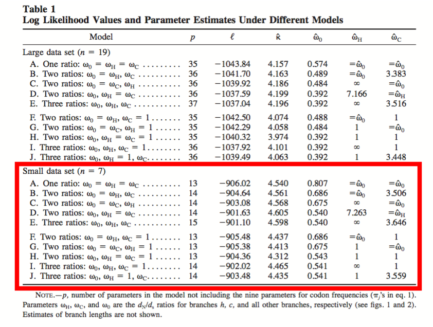

```python
from IPython.display import Image
Image(filename='data/lysozyme/table1_paper.png')
```

El primer modelo que se ejecutaría sería el modelo M0, en el que todas las ramas están condicionadas a evolucionar bajo un único valor de $\omega$ ($\omega_0=\omega_h=\omega_c$)

```python
%%bash
ete3 evol -t data/lysozyme/lysozymeSmall.trees --alg data/lysozyme/lysozymeSmall.txt --model M0
```

```
Using: /home/alex/miniconda3/envs/ete3/bin/ete3_apps/bin/Slr
Using: /home/alex/miniconda3/envs/ete3/bin/ete3_apps/bin/codeml

Running CodeML/Slr (1 CPUs)
  - processing model M0 (M0~81f807526471d24f10a6f69185ed5250)
SUMMARY BY MODEL

 - Model M0
   * Average omega for all tree: 0.807
```

El valor estimado de $\omega$, 0,807, que se muestra aquí en el informe resumido, se corresponde efectivamente con el valor de la tabla (dato bruto A de la sección en cuestión)

A continuación, ejecutaremos un modelo de ramificación que permita que la rama c (antepasado del langur de Douc y del colobo angoleño) evolucione de forma independiente (utilizamos el indicador --mark, indicando los nombres de las dos especies separados por una doble coma, lo que significa que queremos marcar únicamente al antepasado).

```python
%%bash
ete3 evol -t data/lysozyme/lysozymeSmall.trees --alg data/lysozyme/lysozymeSmall.txt --model b_free --clear_all \
--mark Pne_langur,,Cgu/Can_colobus --clear_tree
```

```
Using: /home/alex/miniconda3/envs/ete3/bin/ete3_apps/bin/Slr
Using: /home/alex/miniconda3/envs/ete3/bin/ete3_apps/bin/codeml

Running CodeML/Slr (1 CPUs)
  - processing model b_free (b_free~5c74e86d6c8e0f258a8564d15da7b01b)
       marking branches 11

          ((Hsa_Human,Hla_gibbon),((Cgu/Can_colobus,Pne_langur) #1,Mmu_rhesus),(Ssc_squirrelM,Cja_marmoset));

SUMMARY BY MODEL

 - Model b_free.11-1
   * Marked branches
      ((Hsa_Human,Hla_gibbon),((Cgu/Can_colobus,Pne_langur) #1,Mmu_rhesus),(Ssc_squirrelM,Cja_marmoset));

        Branches  =>   omega
      background  =>   0.686
              #1  =>   3.506
```

En esta ocasión, se estiman dos valores de omega: uno para la rama marcada (n.º 1, $\omega_c$ en la tabla) y otro correspondiente al resto del árbol, al que se suele denominar omega de «fondo» o $\omega_0$. Una vez más, los valores estimados aquí son equivalentes a los de la tabla.

**Nota:** el uso de la opción --clear_tree eliminará todas las marcas presentes en el árbol de entrada antes de iniciar el análisis.

Ahora repetimos el análisis marcando la rama h:

```python
%%bash
ete3 evol -t data/lysozyme/lysozymeSmall.trees --alg data/lysozyme/lysozymeSmall.txt --model b_free --clear_all \
--mark Hsa_Human,,Hla_gibbon --clear_tree
```

```
Using: /home/alex/miniconda3/envs/ete3/bin/ete3_apps/bin/Slr
Using: /home/alex/miniconda3/envs/ete3/bin/ete3_apps/bin/codeml

Running CodeML/Slr (1 CPUs)
  - processing model b_free (b_free~5c74e86d6c8e0f258a8564d15da7b01b)
       marking branches 9

          ((Hsa_Human,Hla_gibbon) #1,((Cgu/Can_colobus,Pne_langur),Mmu_rhesus),(Ssc_squirrelM,Cja_marmoset));

SUMMARY BY MODEL

 - Model b_free.9-1
   * Marked branches
      ((Hsa_Human,Hla_gibbon) #1,((Cgu/Can_colobus,Pne_langur),Mmu_rhesus),(Ssc_squirrelM,Cja_marmoset));

        Branches  =>   omega
      background  =>   0.675
              #1  => 999.000
```

Volvemos a obtener el mismo resultado que en la Tabla 1 ($\omega$ de 999 equivale a infinito).

Para el modelo D. de la Tabla 1, necesitamos marcar dos ramas con la misma marca, lo cual se puede hacer mediante la línea de comandos con --mark Hsa_Human,,Hla_gibbon=Pne_langur,,Cgu/Can_colobus o, quizás, para este caso más complicado, utilizando fácilmente el indicador --interactive. Este indicador te permitirá hacer clic en los nodos que se desean marcar:

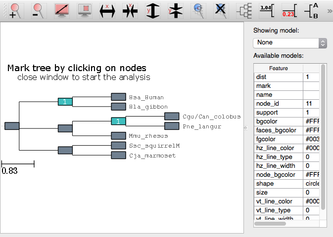

```python
from IPython.display import Image
Image(filename='data/lysozyme/marking_tree_b_free_1_1.png')
```

**Nota:** tras cerrar esta ventana, aparecerá otra ventana en caso de que quieras volver a marcar el árbol para realizar un análisis adicional. Solo tienes que cerrar la segunda ventana y el análisis comenzará.

```python
%%bash
ete3 evol -t data/lysozyme/lysozymeSmall.trees --alg data/lysozyme/lysozymeSmall.txt --model b_free \
--clear_tree --clear_all --interactive
```

[output not shown]

Para el modelo E. de la Tabla 1, distinguiremos de forma diferente las ramas h y c:

```python
%%bash
ete3 evol -t data/lysozyme/lysozymeSmall.trees --alg data/lysozyme/lysozymeSmall.txt --model b_free --clear_all \
--clear_tree --mark Hsa_Human,,Hla_gibbon,Pne_langur,,Cgu/Can_colobus
```

```
Using: /home/alex/miniconda3/envs/ete3/bin/ete3_apps/bin/Slr
Using: /home/alex/miniconda3/envs/ete3/bin/ete3_apps/bin/codeml

Running CodeML/Slr (1 CPUs)
  - processing model b_free (b_free~5c74e86d6c8e0f258a8564d15da7b01b)
       marking branches 9, 11

          ((Hsa_Human,Hla_gibbon) #1,((Cgu/Can_colobus,Pne_langur) #2,Mmu_rhesus),(Ssc_squirrelM,Cja_marmoset));

SUMMARY BY MODEL

 - Model b_free.9_11-1_2
   * Marked branches
      ((Hsa_Human,Hla_gibbon) #1,((Cgu/Can_colobus,Pne_langur) #2,Mmu_rhesus),(Ssc_squirrelM,Cja_marmoset));

        Branches  =>   omega
              #2  =>   3.646
      background  =>   0.540
              #1  => 999.000
```

Para los siguientes modelos, del F al H, los ejecutaremos todos a la vez mediante la línea de comandos (dado que son tres modelos, utilizaremos tres procesadores o CPU):

```python
%%bash
ete3 evol -t data/lysozyme/lysozymeSmall.trees --alg data/lysozyme/lysozymeSmall.txt --model b_neut --clear_all \
--clear_tree --cpu 3 \
--mark Pne_langur,,Cgu/Can_colobus Hsa_Human,,Hla_gibbon Hsa_Human,,Hla_gibbon=Pne_langur,,Cgu/Can_colobus
```

```
Using: /home/alex/miniconda3/envs/ete3/bin/ete3_apps/bin/Slr
Using: /home/alex/miniconda3/envs/ete3/bin/ete3_apps/bin/codeml

Running CodeML/Slr (3 CPUs)
  - processing model b_neut (b_neut~1426df84ff6e0c2233574d5d6f91074a)
       marking branches 11

          ((Hsa_Human,Hla_gibbon),((Cgu/Can_colobus,Pne_langur) #1,Mmu_rhesus),(Ssc_squirrelM,Cja_marmoset));

       marking branches 9

          ((Hsa_Human,Hla_gibbon) #1,((Cgu/Can_colobus,Pne_langur),Mmu_rhesus),(Ssc_squirrelM,Cja_marmoset));

       marking branches 9, 11

          ((Hsa_Human,Hla_gibbon) #1,((Cgu/Can_colobus,Pne_langur) #1,Mmu_rhesus),(Ssc_squirrelM,Cja_marmoset));

SUMMARY BY MODEL

 - Model b_neut.11-1
   * Marked branches
      ((Hsa_Human,Hla_gibbon),((Cgu/Can_colobus,Pne_langur) #1,Mmu_rhesus),(Ssc_squirrelM,Cja_marmoset));

        Branches  =>   omega
      background  =>   0.686
              #1  =>   1.000

 - Model b_neut.9-1
   * Marked branches
      ((Hsa_Human,Hla_gibbon) #1,((Cgu/Can_colobus,Pne_langur),Mmu_rhesus),(Ssc_squirrelM,Cja_marmoset));

        Branches  =>   omega
      background  =>   0.675
              #1  =>   1.000

 - Model b_neut.9_11-1_1
   * Marked branches
      ((Hsa_Human,Hla_gibbon) #1,((Cgu/Can_colobus,Pne_langur) #1,Mmu_rhesus),(Ssc_squirrelM,Cja_marmoset));

        Branches  =>   omega
      background  =>   0.543
              #1  =>   1.000
```

Hemos utilizado el modelo b_neut, que fijará el valor de $\omega$ en 1 en las ramas etiquetadas con la última marca (en este caso, la n.º 1).

Ahora ejecutaremos conjuntamente los dos últimos modelos propuestos en la Tabla 1 (modelos I y J). En esta ocasión, la última marca debe colocarse, respectivamente, en la rama c y en la rama h:

```python
%%bash
ete3 evol -t data/lysozyme/lysozymeSmall.trees --alg data/lysozyme/lysozymeSmall.txt --model b_neut --clear_all \
--clear_tree --cpu 2 \
--mark Hsa_Human,,Hla_gibbon,Pne_langur,,Cgu/Can_colobus Pne_langur,,Cgu/Can_colobus,Hsa_Human,,Hla_gibbon
```

```
Using: /home/alex/miniconda3/envs/ete3/bin/ete3_apps/bin/Slr
Using: /home/alex/miniconda3/envs/ete3/bin/ete3_apps/bin/codeml

Running CodeML/Slr (2 CPUs)
  - processing model b_neut (b_neut~1426df84ff6e0c2233574d5d6f91074a)
       marking branches 9, 11

          ((Hsa_Human,Hla_gibbon) #1,((Cgu/Can_colobus,Pne_langur) #2,Mmu_rhesus),(Ssc_squirrelM,Cja_marmoset));

       marking branches 11, 9

          ((Hsa_Human,Hla_gibbon) #2,((Cgu/Can_colobus,Pne_langur) #1,Mmu_rhesus),(Ssc_squirrelM,Cja_marmoset));

SUMMARY BY MODEL

 - Model b_neut.9_11-1_2
   * Marked branches
      ((Hsa_Human,Hla_gibbon) #1,((Cgu/Can_colobus,Pne_langur) #2,Mmu_rhesus),(Ssc_squirrelM,Cja_marmoset));

        Branches  =>   omega
              #2  =>   1.000
              #1  => 999.000
      background  =>   0.541

 - Model b_neut.11_9-1_2
   * Marked branches
      ((Hsa_Human,Hla_gibbon) #2,((Cgu/Can_colobus,Pne_langur) #1,Mmu_rhesus),(Ssc_squirrelM,Cja_marmoset));

        Branches  =>   omega
              #1  =>   3.559
      background  =>   0.541
              #2  =>   1.000
```

**Pruebas de la razón de verosimilitud**

En la sección anterior hemos estimado las presiones selectivas según varios modelos evolutivos. Para determinar cuál de estos modelos es el más probable, Ziheng Yang utiliza la prueba de la razón de verosimilitud (LRT) entre pares de modelos. El resultado de estas pruebas se presenta en la Tabla 2 de su artículo (de nuevo, el rectángulo rojo señala los resultados correspondientes al pequeño conjunto de datos que nos interesa):

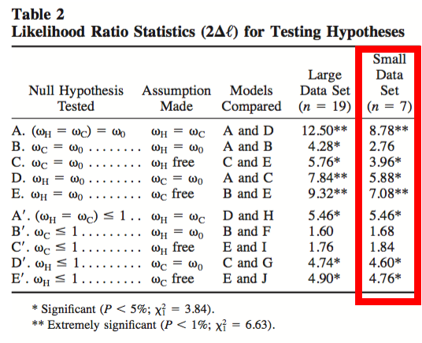

```python
from IPython.display import Image
Image(filename='data/lysozyme/table2_paper.png')
```

Por defecto, la herramienta ete_evol calcula todos los LRT posibles entre los modelos calculados. Por lo tanto, si ejecutamos todos los modelos ejecutados anteriormente, obtendremos una tabla de LRT comparable a la del artículo. Nota: aquí utilizamos el parámetro --resume para omitir el cálculo y limitarnos a analizar los resultados anteriores.

```python
%%bash
ete3 evol -t data/lysozyme/lysozymeSmall.trees --alg data/lysozyme/lysozymeSmall.txt --model M0 b_free b_neut \
--resume --clear_tree \
--mark Pne_langur,,Cgu/Can_colobus Hsa_Human,,Hla_gibbon Hsa_Human,,Hla_gibbon=Pne_langur,,Cgu/Can_colobus \
Pne_langur,,Cgu/Can_colobus,Hsa_Human,,Hla_gibbon Hsa_Human,,Hla_gibbon,Pne_langur,,Cgu/Can_colobus
```

```
Using: /home/alex/miniconda3/envs/ete3/bin/ete3_apps/bin/Slr
Using: /home/alex/miniconda3/envs/ete3/bin/ete3_apps/bin/codeml

Running CodeML/Slr (1 CPUs)
  - processing model M0 (M0~81f807526471d24f10a6f69185ed5250)
  - processing model b_free (b_free~5c74e86d6c8e0f258a8564d15da7b01b)
       marking branches 11

          ((Hsa_Human,Hla_gibbon),((Cgu/Can_colobus,Pne_langur) #1,Mmu_rhesus),(Ssc_squirrelM,Cja_marmoset));

       marking branches 9

          ((Hsa_Human,Hla_gibbon) #1,((Cgu/Can_colobus,Pne_langur),Mmu_rhesus),(Ssc_squirrelM,Cja_marmoset));

       marking branches 9, 11

          ((Hsa_Human,Hla_gibbon) #1,((Cgu/Can_colobus,Pne_langur) #1,Mmu_rhesus),(Ssc_squirrelM,Cja_marmoset));

       marking branches 11, 9

          ((Hsa_Human,Hla_gibbon) #2,((Cgu/Can_colobus,Pne_langur) #1,Mmu_rhesus),(Ssc_squirrelM,Cja_marmoset));

       marking branches 9, 11

          ((Hsa_Human,Hla_gibbon) #1,((Cgu/Can_colobus,Pne_langur) #2,Mmu_rhesus),(Ssc_squirrelM,Cja_marmoset));

  - processing model b_neut (b_neut~1426df84ff6e0c2233574d5d6f91074a)
       marking branches 11

          ((Hsa_Human,Hla_gibbon),((Cgu/Can_colobus,Pne_langur) #1,Mmu_rhesus),(Ssc_squirrelM,Cja_marmoset));

       marking branches 9

          ((Hsa_Human,Hla_gibbon) #1,((Cgu/Can_colobus,Pne_langur),Mmu_rhesus),(Ssc_squirrelM,Cja_marmoset));

       marking branches 9, 11

          ((Hsa_Human,Hla_gibbon) #1,((Cgu/Can_colobus,Pne_langur) #1,Mmu_rhesus),(Ssc_squirrelM,Cja_marmoset));

       marking branches 11, 9
```

[output cut: 96 more lines]

```
      ((Hsa_Human,Hla_gibbon) #2,((Cgu/Can_colobus,Pne_langur) #1,Mmu_rhesus),(Ssc_squirrelM,Cja_marmoset));

        Branches  =>   omega
              #2  =>   1.000
      background  =>   0.541
              #1  =>   3.559

 - Model b_neut.9_11-1_2
   * Marked branches
      ((Hsa_Human,Hla_gibbon) #1,((Cgu/Can_colobus,Pne_langur) #2,Mmu_rhesus),(Ssc_squirrelM,Cja_marmoset));

        Branches  =>   omega
              #2  =>   1.000
              #1  => 999.000
      background  =>   0.541
```

**Reproducir el análisis CODEML de Yang Z (MBE, 2005)**

Este manual tiene como objetivo reproducir los resultados sobre la selección en sitios presentados en el trabajo de Yang Z (MBE, 2005) utilizando ete-evol.

Se utilizarán los archivos de datos adaptados a partir de los ejemplos del paquete PAML; se tratará de un conjunto de datos de gran tamaño.

Estos archivos son:

```python
%%bash
ete3 view -t data/hiv-env/HIVenv.nw --alg data/hiv-env/HIVenv.fasta --alg_type compactseq \
-i data/hiv-env/HIVenv.png
```

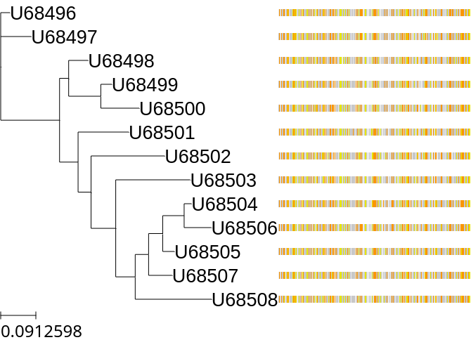

```python
from IPython.display import Image
Image(filename='data/hiv-env/HIVenv.png')
```

En concreto, nuestro objetivo es reproducir la Tabla 4:

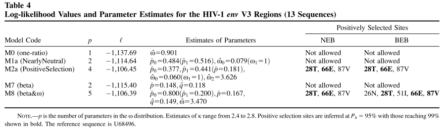

```python
from IPython.display import Image
Image(filename='data/lysozyme/table4_YangZ_2005.png')
```

```python
%%bash
ete3 evol -t data/hiv-env/HIVenv.nw --alg data/hiv-env/HIVenv.fasta --models M0 M1 M2 M7 M8 -o /tmp/ete3-HIV/ \
--clear_all --cpu 5 -i data/hiv-env/HIVenv.png --histface bar +-curve bar +-bar
```

```
Using: /home/alex/miniconda3/envs/ete3/bin/ete3_apps/bin/Slr
Using: /home/alex/miniconda3/envs/ete3/bin/ete3_apps/bin/codeml

Running CodeML/Slr (5 CPUs)
  - processing model M0 (M0~ff3401ba9234dad3d00348aee0c4af83)
  - processing model M1 (M1~a2c9018c6f6e58a51e000bdbd330be55)
  - processing model M2 (M2~c71c2623caa1966625eab8d44483fbe1)
  - processing model M7 (M7~a4085b7a04583bb4a435c7966451b542)
  - processing model M8 (M8~05591729624106088540168a40e04d23)

LRT

                                         Null model |                             Alternative model | p-value
   =================================================|===============================================|============
                M0~ff3401ba9234dad3d00348aee0c4af83 |           M1~a2c9018c6f6e58a51e000bdbd330be55 | 0.000000**
                M0~ff3401ba9234dad3d00348aee0c4af83 |           M2~c71c2623caa1966625eab8d44483fbe1 | 0.000000**
                M0~ff3401ba9234dad3d00348aee0c4af83 |           M7~a4085b7a04583bb4a435c7966451b542 | 0.000000**
                M0~ff3401ba9234dad3d00348aee0c4af83 |           M8~05591729624106088540168a40e04d23 | 0.000000**
                M1~a2c9018c6f6e58a51e000bdbd330be55 |           M2~c71c2623caa1966625eab8d44483fbe1 | 0.000276**
                M1~a2c9018c6f6e58a51e000bdbd330be55 |           M8~05591729624106088540168a40e04d23 | 0.000260**
                M7~a4085b7a04583bb4a435c7966451b542 |           M2~c71c2623caa1966625eab8d44483fbe1 | 0.000129**
                M7~a4085b7a04583bb4a435c7966451b542 |           M8~05591729624106088540168a40e04d23 | 0.000122**

SUMMARY BY MODEL

 - Model M0
   * Average omega for all tree: 0.901

 - Model M1
   * Average omega for all tree: 0.554
   * Sites significantly caracterized
      codon position |   category
     -----------------------------------------------------------
                 1   |   Relaxed (probability > 0.99)
                 4   |   Conserved (probability > 0.95)
                 6   |   Conserved (probability > 0.95)
                 9   |   Relaxed (probability > 0.99)
                13   |   Conserved (probability > 0.95)
           15-  16   |   Conserved (probability > 0.95)
           21-  22   |   Relaxed (probability > 0.99)
```

[output cut: 31 more lines]

```
                87   |   Positively-selected (probability > 0.95)

 - Model M7
   * Average omega for all tree: 0.548

 - Model M8
   * Average omega for all tree: 1.120
   * Sites significantly caracterized
      codon position |   category
     -----------------------------------------------------------
                26   |   Positively-selected (probability > 0.95)
                28   |   Positively-selected (probability > 0.99)
                51   |   Positively-selected (probability > 0.95)
                66   |   Positively-selected (probability > 0.99)
                87   |   Positively-selected (probability > 0.99)
```

Según la tabla LRT, en este ejemplo siempre son más probables los modelos que permiten que la clase de sitios evolucione a valores de $\omega$ superiores a 1.

El resumen de los modelos M2 y M8 muestra los sitios (posición del codón en la alineación) que, según la estimación BEB, se encuentran bajo selección positiva en cada modelo. Estos sitios se corresponden con los resultados presentados en el artículo.

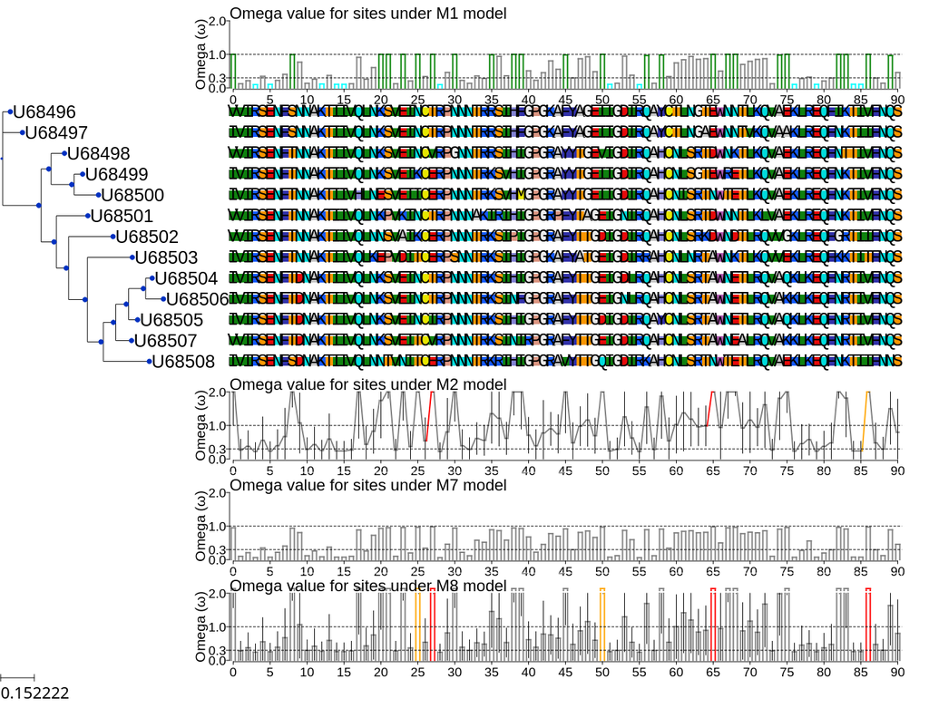

```python
from IPython.display import Image
Image(filename='data/hiv-env/HIVenv.png')
```

## Ejecutar el ejemplo de PAML tal cual

Los archivos que vamos a utilizar para este ejemplo son:

data/lysozyme/lysozymeSmall.txt  
data/lysozyme/lysozymeSmall.trees  
data/lysozyme/lysozymeSmall.ctl

Las herramientas de ete_evol permiten ejecutar CodeML directamente utilizando un archivo de configuración de PAML.

```python
%%bash
cat data/lysozyme/lysozymeSmall.ctl
```

```
      seqfile = lysozymeSmall.txt
     treefile = lysozymeSmall.trees
      outfile = mlc

        noisy = 9   * 0,1,2,3,9: how much rubbish on the screen
      verbose = 1   * 1: detailed output, 0: concise output
      runmode = 0   * 0: user tree;  1: semi-automatic;  2: automatic
                    * 3: StepwiseAddition; (4,5):PerturbationNNI

      seqtype = 1   * 1:codons; 2:AAs; 3:codons-->AAs
    CodonFreq = 2   * 0:1/61 each, 1:F1X4, 2:F3X4, 3:codon table
        clock = 0   * 0: no clock, unrooted tree, 1: clock, rooted tree
        model = 2
                    * models for codons:
                        * 0:one, 1:b, 2:2 or more dN/dS ratios for branches

      NSsites = 0   * dN/dS among sites. 0:no variation, 1:neutral, 2:positive
        icode = 0   * 0:standard genetic code; 1:mammalian mt; 2-10:see below

    fix_kappa = 0   * 1: kappa fixed, 0: kappa to be estimated
        kappa = 2   * initial or fixed kappa
    fix_omega = 0   * 1: omega or omega_1 fixed, 0: estimate
        omega = 2   * initial or fixed omega, for codons or codon-transltd AAs

    fix_alpha = 1   * 0: estimate gamma shape parameter; 1: fix it at alpha
        alpha = .0  * initial or fixed alpha, 0:infinity (constant rate)
       Malpha = 0   * different alphas for genes
        ncatG = 4   * # of categories in the dG or AdG models of rates

        getSE = 0   * 0: don't want them, 1: want S.E.s of estimates
 RateAncestor = 0   * (1/0): rates (alpha>0) or ancestral states (alpha=0)
       method = 0   * 0: simultaneous; 1: one branch at a time


* Specifications for duplicating results for the small data set in table 1
* of Yang (1998 MBE 15:568-573).
* see the tree file lysozyme.trees for specification of node (branch) labels
```

El archivo de configuración anterior corresponde a un modelo de ramificación en el que las ramas marcadas pueden evolucionar a una tasa $\omega$ diferente a la de las ramas no marcadas. En este ejemplo de PAML, la rama marcada es la rama c (el antepasado del colobo angoleño y del langur douc). Véase el árbol del ejemplo de PAML:

```python
%%bash
head data/lysozyme/lysozymeSmall.trees
```

```
    1


((Hsa_Human, Hla_gibbon),((Cgu/Can_colobus, Pne_langur) '#1', Mmu_rhesus), (Ssc_squirrelM, Cja_marmoset)); / * table 1B&F */


// end of file
```

Para ejecutar codeml desde la herramienta ete_evol utilizando este archivo de configuración, habría que hacer lo siguiente:

```python
%%bash
ete3 evol --codeml_config_file data/lysozyme/lysozymeSmall.ctl
```

```
Using: /home/alex/miniconda3/envs/ete3/bin/ete3_apps/bin/Slr
Using: /home/alex/miniconda3/envs/ete3/bin/ete3_apps/bin/codeml

Running CodeML/Slr (1 CPUs)
  - processing model XX.lysozymeSmall.ctl (XX.lysozymeS~0eeb496dd4cb62f547211cec3722b5d7)
       marking branches 11

          ((Hsa_Human,Hla_gibbon),((Cgu/Can_colobus,Pne_langur) #1,Mmu_rhesus),(Ssc_squirrelM,Cja_marmoset));

SUMMARY BY MODEL

 - Model XX.lysozymeSmall.ctl.11-1
   * Marked branches
      ((Hsa_Human,Hla_gibbon),((Cgu/Can_colobus,Pne_langur) #1,Mmu_rhesus),(Ssc_squirrelM,Cja_marmoset));

        Branches  =>   omega
              #1  =>   3.506
      background  =>   0.686
```

Además, la herramienta ete_evol generará una imagen resumen:

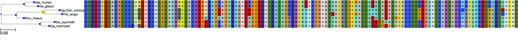

```python
from IPython.display import Image
Image(filename='data/lysozyme/tree_evol_example1.png')
```

Image which can be called interactively using the --view flag:

```python
%%bash
ete3 evol --codeml_config_file data/lysozyme/lysozymeSmall.ctl --view --resume
```

```
Using: /home/alex/miniconda3/envs/ete3/bin/ete3_apps/bin/Slr
Using: /home/alex/miniconda3/envs/ete3/bin/ete3_apps/bin/codeml

Running CodeML/Slr (1 CPUs)
  - processing model XX.lysozymeSmall.ctl (XX.lysozymeS~0eeb496dd4cb62f547211cec3722b5d7)
       marking branches 11

Model XX.lysozymeSmall.ctl.11-1 (XX.lysozymeS~53b17a1ef6025029ccdf36cff8151c47) already executed... SKIPPING
SUMMARY BY MODEL

 - Model XX.lysozymeSmall.ctl.11-1
   * Marked branches
      ((Hsa_Human,Hla_gibbon),((Cgu/Can_colobus,Pne_langur) #1,Mmu_rhesus),(Ssc_squirrelM,Cja_marmoset));

        Branches  =>   omega
              #1  =>   3.506
      background  =>   0.686
```

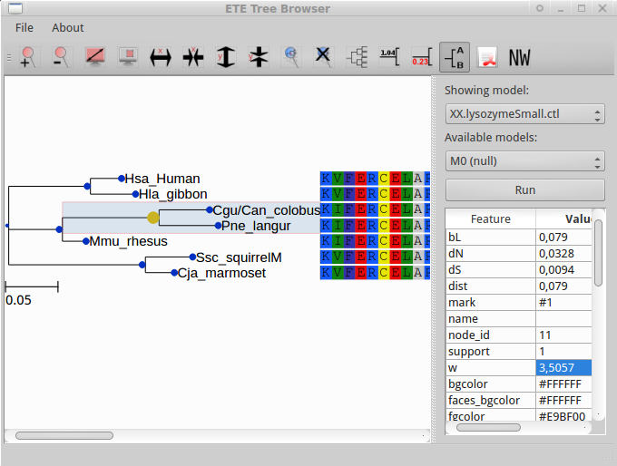

```python
from IPython.display import Image
Image(filename='data/lysozyme/ete_run1_lysozyme.png')
```

# ete-evol

ete-evol es una herramienta que automatiza los análisis de CodeML y Slr mediante el uso de modelos evolutivos preconfigurados y que genera directamente una representación gráfica de los resultados.

**Características destacadas:**

Los modelos preconfigurados incluyen modelos de sitio (Yang et al. 2000; Massingham y Goldman 2005), de rama (Yang y Nielsen 2002), de rama-sitio (Zhang et al. 2005) y de clado (Yang y Nielsen 2002; Bielawski y Yang 2004).

Se pueden probar y visualizar múltiples modelos evolutivos con un único comando.

Los árboles de entrada se pueden marcar de forma interactiva utilizando la interfaz gráfica de usuario de ETE.

Los análisis de CodeML se pueden ajustar con precisión (utilice --codeml_help para ver las opciones).

Las opciones de multihilo permiten ejecutar múltiples pruebas en paralelo.

**Introducción**

**Flujos de trabajo de Evol-tree**

**Conceptos generales**

Para ejecutar un flujo de trabajo evol de ete3 necesitamos un archivo Fasta, un archivo de árbol y un nombre de modelo. Además, si se utilizan modelos de rama o de rama-sitio, se debe proporcionar información adicional para aplicar restricciones evolutivas específicas a secciones del árbol.

Los «nombres de modelo» corresponden a varios modelos evolutivos predefinidos basados en investigaciones publicadas anteriormente (véase la tabla de la siguiente sección y la documentación de PAML y Slr).

Cualquiera de estos modelos predefinidos se puede modificar fácilmente mediante la línea de comandos, por ejemplo: --codeml_param getSE,1.

Una vez ejecutados, los modelos se pueden comparar mediante la prueba de la razón de verosimilitud (LRT). Esto se puede hacer de forma automática (por defecto) o utilizando comparaciones predefinidas (opción --tests).

Modelos evolutivos Con la herramienta se pueden invocar varios modelos evolutivos predefinidos.

[figure not shown]

Se pueden pasar de forma secuencial y ejecutarse en paralelo:

```python
!ete3 evol -t data/ECP_EDN_15.nw --alg data/ECP_EDN_15.fasta -o results1/ --models fb M2 SLR --cpu 4
```

```
Using: /home/alex/miniconda3/envs/ete3/bin/ete3_apps/bin/Slr
Using: /home/alex/miniconda3/envs/ete3/bin/ete3_apps/bin/codeml

Running CodeML/Slr (4 CPUs)
  - processing model fb (fb~041c29bdb9f4112721ccf7460c35a1f9)
  - processing model M2 (M2~642d8083de0b0ebd436286d9753ab222)
  - processing model SLR (SLR~af23c43e24e9e9fbabccb227b6e2e19a)
SUMMARY BY MODEL

 - Model fb
   * Marked branches
      (((Hylobates_EDN #7,(Orang_EDN #13,(Gorilla_EDN #22,(Chimp_EDN #26,Human_EDN #27) #23) #14) #8) #3,(Macaq_EDN #9,(Cercopith_EDN #15,(Macaq2_EDN #24,Papio_EDN #25) #16) #10) #4) #1,(Orang_ECP #5,((Macaq_ECP #17,Macaq2_ECP #18) #11,(Goril_ECP #19,Chimp_ECP #20,Human_ECP #21) #12) #6) #2);

        Branches  =>   omega
             #12  => 999.000
              #7  =>   0.127
             #13  =>   0.762
             #15  =>   0.836
              #6  =>   4.203
             #16  =>   0.000
              #2  =>   0.000
             #10  =>   0.996
             #23  => 999.000
             #14  =>   0.166
              #4  =>   0.478
              #3  =>   2.470
             #11  =>   0.606
             #22  =>   0.353
              #8  =>   0.622
             #24  => 999.000
             #26  =>   0.168
             #17  =>   1.407
             #27  =>   0.000
             #18  => 999.000
             #20  => 999.000
              #9  =>   0.000
             #19  =>   0.690
             #21  => 999.000
             #25  =>   0.000
              #1  => 999.000
              #5  =>   2.922

 - Model M2
   * Average omega for all tree: 1.004
   * Sites significantly caracterized
      codon position |   category
     -----------------------------------------------------------
                30   |   Positively-selected (probability > 0.95)
               103   |   Positively-selected (probability > 0.99)

 - Model SLR
   * Sites significantly caracterized
      codon position |   category
     -----------------------------------------------------------
                30   |   Positively-selected (probability > 0.95)
               103   |   Positively-selected (probability > 0.95)
```

**Marcado de árboles**

Una de las principales dificultades a la hora de automatizar CodeML para varios árboles es marcar las ramas específicamente para cada modelo que se vaya a ejecutar. ete3 evol permite pasar listas de marcas que se aplicarán a cada modelo de rama deseado.

El árbol se puede marcar desde la línea de comandos de la siguiente manera:

```python
!ete3 evol -t data/ECP_EDN_15.nw --alg data/ECP_EDN_15.fasta --models b_neut b_free --mark Papio_EDN,,,Orang_EDN -o results2/
```

```
Using: /home/alex/miniconda3/envs/ete3/bin/ete3_apps/bin/Slr
Using: /home/alex/miniconda3/envs/ete3/bin/ete3_apps/bin/codeml

Running CodeML/Slr (1 CPUs)
  - processing model b_neut (b_neut~9dbb67dbc0d142d8e59fa0b80e2c11f0)
       marking branches 18, 22, 8, 19, 12, 23, 14, 20, 1, 24, 5, 21, 10, 15, 3, 7, 17

          (((Hylobates_EDN #1,(Orang_EDN #1,(Gorilla_EDN #1,(Chimp_EDN #1,Human_EDN #1) #1) #1) #1) #1,(Macaq_EDN #1,(Cercopith_EDN #1,(Macaq2_EDN #1,Papio_EDN #1) #1) #1) #1) #1,(Orang_ECP,((Macaq_ECP,Macaq2_ECP),(Goril_ECP,Chimp_ECP,Human_ECP))));

  - processing model b_free (b_free~b02bb7e311a26eee5b52d13a25a757aa)
       marking branches 18, 22, 8, 19, 12, 23, 14, 20, 1, 24, 5, 21, 10, 15, 3, 7, 17

          (((Hylobates_EDN #1,(Orang_EDN #1,(Gorilla_EDN #1,(Chimp_EDN #1,Human_EDN #1) #1) #1) #1) #1,(Macaq_EDN #1,(Cercopith_EDN #1,(Macaq2_EDN #1,Papio_EDN #1) #1) #1) #1) #1,(Orang_ECP,((Macaq_ECP,Macaq2_ECP),(Goril_ECP,Chimp_ECP,Human_ECP))));


LRT

                                         Null model |                             Alternative model | p-value
   =================================================|===============================================|============
      b_neut.18_22~ef02f19d1f4764b407f5f2735bcb08b9 | b_free.18_22~cb44ce0c6ab30ea277e2c170cf13b5d8 | 0.002473**

SUMMARY BY MODEL

 - Model b_neut.18_22_8_19_12_23_14_20_1_24_5_21_10_15_3_7_17-1_1_1_1_1_1_1_1_1_1_1_1_1_1_1_1_1
   * Marked branches
      (((Hylobates_EDN #1,(Orang_EDN #1,(Gorilla_EDN #1,(Chimp_EDN #1,Human_EDN #1) #1) #1) #1) #1,(Macaq_EDN #1,(Cercopith_EDN #1,(Macaq2_EDN #1,Papio_EDN #1) #1) #1) #1) #1,(Orang_ECP,((Macaq_ECP,Macaq2_ECP),(Goril_ECP,Chimp_ECP,Human_ECP))));

        Branches  =>   omega
              #1  =>   1.000
      background  =>   1.690

 - Model b_free.18_22_8_19_12_23_14_20_1_24_5_21_10_15_3_7_17-1_1_1_1_1_1_1_1_1_1_1_1_1_1_1_1_1
   * Marked branches
      (((Hylobates_EDN #1,(Orang_EDN #1,(Gorilla_EDN #1,(Chimp_EDN #1,Human_EDN #1) #1) #1) #1) #1,(Macaq_EDN #1,(Cercopith_EDN #1,(Macaq2_EDN #1,Papio_EDN #1) #1) #1) #1) #1,(Orang_ECP,((Macaq_ECP,Macaq2_ECP),(Goril_ECP,Chimp_ECP,Human_ECP))));

        Branches  =>   omega
              #1  =>   0.510
      background  =>   1.686
```

Las tres comas indican que el árbol se marcará a partir del antepasado común de las especies circundantes. Para marcar en el nodo ancestral, tendríamos que poner solo dos comas.

Este código de comas permite marcar fácilmente cualquier parte del árbol; al utilizar una sola coma se crean nuevas marcas. Por último, los espacios entre los parámetros bajo --marks separan los conjuntos de marcas. Cada modelo de rama se ejecutará en cada conjunto de marcas. Por ejemplo:

```python
!ete3 evol -t data/ECP_EDN_15.nw --alg data/ECP_EDN_15.fasta --models b_neut b_free --mark Human_EDN,,,Hylobates_EDN,Macaq_EDN,,,Papio_EDN Macaq_ECP,,Macaq2_ECP,Human_ECP,,Goril_ECP -o results3/
```

```
Using: /home/alex/miniconda3/envs/ete3/bin/ete3_apps/bin/Slr
Using: /home/alex/miniconda3/envs/ete3/bin/ete3_apps/bin/codeml

Running CodeML/Slr (1 CPUs)
  - processing model b_neut (b_neut~9dbb67dbc0d142d8e59fa0b80e2c11f0)
       marking branches 8, 19, 14, 20, 5, 21, 3, 7, 18, 12, 23, 1, 24, 10, 15, 22

          (((Hylobates_EDN #1,(Orang_EDN #1,(Gorilla_EDN #1,(Chimp_EDN #1,Human_EDN #1) #1) #1) #1) #1,(Macaq_EDN #2,(Cercopith_EDN #2,(Macaq2_EDN #2,Papio_EDN #2) #2) #2) #2),(Orang_ECP,((Macaq_ECP,Macaq2_ECP),(Goril_ECP,Chimp_ECP,Human_ECP))));

       marking branches 27, 28

          (((Hylobates_EDN,(Orang_EDN,(Gorilla_EDN,(Chimp_EDN,Human_EDN)))),(Macaq_EDN,(Cercopith_EDN,(Macaq2_EDN,Papio_EDN)))),(Orang_ECP,((Macaq_ECP,Macaq2_ECP) #1,(Goril_ECP,Chimp_ECP,Human_ECP) #2)));

  - processing model b_free (b_free~b02bb7e311a26eee5b52d13a25a757aa)
       marking branches 8, 19, 14, 20, 5, 21, 3, 7, 18, 12, 23, 1, 24, 10, 15, 22

          (((Hylobates_EDN #1,(Orang_EDN #1,(Gorilla_EDN #1,(Chimp_EDN #1,Human_EDN #1) #1) #1) #1) #1,(Macaq_EDN #2,(Cercopith_EDN #2,(Macaq2_EDN #2,Papio_EDN #2) #2) #2) #2),(Orang_ECP,((Macaq_ECP,Macaq2_ECP),(Goril_ECP,Chimp_ECP,Human_ECP))));

       marking branches 27, 28

          (((Hylobates_EDN,(Orang_EDN,(Gorilla_EDN,(Chimp_EDN,Human_EDN)))),(Macaq_EDN,(Cercopith_EDN,(Macaq2_EDN,Papio_EDN)))),(Orang_ECP,((Macaq_ECP,Macaq2_ECP) #1,(Goril_ECP,Chimp_ECP,Human_ECP) #2)));


LRT

                                         Null model |                             Alternative model | p-value
   =================================================|===============================================|============
      b_neut.8_19_~f8f8ef7d0ed8ec9881c120a1a8e9c7cf | b_free.8_19_~7713b691eedc44aa72c371768d206bf1 | 0.100009
      b_neut.27_28~d79d104f30dda9ade0bdb929db488645 | b_free.27_28~197e76ae54aae5ab2245d0784071e7e3 | 0.158918

SUMMARY BY MODEL

 - Model b_neut.8_19_14_20_5_21_3_7_18_12_23_1_24_10_15_22-1_1_1_1_1_1_1_1_1_2_2_2_2_2_2_2
   * Marked branches
      (((Hylobates_EDN #1,(Orang_EDN #1,(Gorilla_EDN #1,(Chimp_EDN #1,Human_EDN #1) #1) #1) #1) #1,(Macaq_EDN #2,(Cercopith_EDN #2,(Macaq2_EDN #2,Papio_EDN #2) #2) #2) #2),(Orang_ECP,((Macaq_ECP,Macaq2_ECP),(Goril_ECP,Chimp_ECP,Human_ECP))));

        Branches  =>   omega
              #2  =>   1.000
      background  =>   1.688
              #1  =>   0.448
```

[output cut: 12 more lines]

```
      (((Hylobates_EDN #1,(Orang_EDN #1,(Gorilla_EDN #1,(Chimp_EDN #1,Human_EDN #1) #1) #1) #1) #1,(Macaq_EDN #2,(Cercopith_EDN #2,(Macaq2_EDN #2,Papio_EDN #2) #2) #2) #2),(Orang_ECP,((Macaq_ECP,Macaq2_ECP),(Goril_ECP,Chimp_ECP,Human_ECP))));

        Branches  =>   omega
      background  =>   1.686
              #2  =>   0.580
              #1  =>   0.454

 - Model b_free.27_28-1_2
   * Marked branches
      (((Hylobates_EDN,(Orang_EDN,(Gorilla_EDN,(Chimp_EDN,Human_EDN)))),(Macaq_EDN,(Cercopith_EDN,(Macaq2_EDN,Papio_EDN)))),(Orang_ECP,((Macaq_ECP,Macaq2_ECP) #1,(Goril_ECP,Chimp_ECP,Human_ECP) #2)));

        Branches  =>   omega
      background  =>   0.857
              #2  => 999.000
              #1  =>   0.603
```

Cuando, como en el ejemplo anterior, se pasan marcas consecutivas, los modelos indicados («b_neut» y «b_free» en este caso) se ejecutarán de forma independiente para cada grupo de marcas.

**Funciones adicionales:**

Esta imagen se guarda en formato PDF en el directorio de salida, a menos que se utilice la opción --noimg. La opción --view permite visualizar esta imagen en la interfaz gráfica de usuario de ETE e interactuar con ella. La interfaz gráfica de usuario permite examinar todos los modelos ejecutados y comparar las diferentes estimaciones de las tasas evolutivas. Por último, también se pueden ejecutar nuevos modelos directamente desde la interfaz gráfica de usuario (véase la sección sobre la interfaz gráfica de usuario).

```python
!ete3 evol -t data/ECP_EDN_15.nw --alg data/ECP_EDN_15.fasta --models b_neut b_free --mark Papio_EDN,,,Orang_EDN -o results3/
```

```
Using: /home/alex/miniconda3/envs/ete3/bin/ete3_apps/bin/Slr
Using: /home/alex/miniconda3/envs/ete3/bin/ete3_apps/bin/codeml

Running CodeML/Slr (1 CPUs)
  - processing model b_neut (b_neut~9dbb67dbc0d142d8e59fa0b80e2c11f0)
       marking branches 18, 22, 8, 19, 12, 23, 14, 20, 1, 24, 5, 21, 10, 15, 3, 7, 17

          (((Hylobates_EDN #1,(Orang_EDN #1,(Gorilla_EDN #1,(Chimp_EDN #1,Human_EDN #1) #1) #1) #1) #1,(Macaq_EDN #1,(Cercopith_EDN #1,(Macaq2_EDN #1,Papio_EDN #1) #1) #1) #1) #1,(Orang_ECP,((Macaq_ECP,Macaq2_ECP),(Goril_ECP,Chimp_ECP,Human_ECP))));

  - processing model b_free (b_free~b02bb7e311a26eee5b52d13a25a757aa)
       marking branches 18, 22, 8, 19, 12, 23, 14, 20, 1, 24, 5, 21, 10, 15, 3, 7, 17

          (((Hylobates_EDN #1,(Orang_EDN #1,(Gorilla_EDN #1,(Chimp_EDN #1,Human_EDN #1) #1) #1) #1) #1,(Macaq_EDN #1,(Cercopith_EDN #1,(Macaq2_EDN #1,Papio_EDN #1) #1) #1) #1) #1,(Orang_ECP,((Macaq_ECP,Macaq2_ECP),(Goril_ECP,Chimp_ECP,Human_ECP))));


LRT

                                         Null model |                             Alternative model | p-value
   =================================================|===============================================|============
      b_neut.18_22~ef02f19d1f4764b407f5f2735bcb08b9 | b_free.18_22~cb44ce0c6ab30ea277e2c170cf13b5d8 | 0.002473**

SUMMARY BY MODEL

 - Model b_neut.18_22_8_19_12_23_14_20_1_24_5_21_10_15_3_7_17-1_1_1_1_1_1_1_1_1_1_1_1_1_1_1_1_1
   * Marked branches
      (((Hylobates_EDN #1,(Orang_EDN #1,(Gorilla_EDN #1,(Chimp_EDN #1,Human_EDN #1) #1) #1) #1) #1,(Macaq_EDN #1,(Cercopith_EDN #1,(Macaq2_EDN #1,Papio_EDN #1) #1) #1) #1) #1,(Orang_ECP,((Macaq_ECP,Macaq2_ECP),(Goril_ECP,Chimp_ECP,Human_ECP))));

        Branches  =>   omega
      background  =>   1.690
              #1  =>   1.000

 - Model b_free.18_22_8_19_12_23_14_20_1_24_5_21_10_15_3_7_17-1_1_1_1_1_1_1_1_1_1_1_1_1_1_1_1_1
   * Marked branches
      (((Hylobates_EDN #1,(Orang_EDN #1,(Gorilla_EDN #1,(Chimp_EDN #1,Human_EDN #1) #1) #1) #1) #1,(Macaq_EDN #1,(Cercopith_EDN #1,(Macaq2_EDN #1,Papio_EDN #1) #1) #1) #1) #1,(Orang_ECP,((Macaq_ECP,Macaq2_ECP),(Goril_ECP,Chimp_ECP,Human_ECP))));

        Branches  =>   omega
              #1  =>   0.510
      background  =>   1.686
```

## Comprobación de modelos evolutivos

Con el fin de comparar cuál de los diferentes modelos calculados se ajusta mejor a los datos de entrada, la herramienta ete3 evol comprueba, mediante una prueba LRT, cualquier par de modelos calculados. Por defecto, realizará las comparaciones más clásicas, como las que se incluyen en la tabla siguiente.

[figure not shown]

```python
!ete3 evol -t data/ECP_EDN_15.nw --alg data/ECP_EDN_15.fasta --models M2 M1 b_free b_neut --leaves --tests b_free,b_neut -o results4/
```

```
Using: /home/alex/miniconda3/envs/ete3/bin/ete3_apps/bin/Slr
Using: /home/alex/miniconda3/envs/ete3/bin/ete3_apps/bin/codeml

Running CodeML/Slr (1 CPUs)
  - processing model M2 (M2~642d8083de0b0ebd436286d9753ab222)
  - processing model M1 (M1~1ce888c73e3faa46335a78b4064057ff)
  - processing model b_free (b_free~b02bb7e311a26eee5b52d13a25a757aa)
       marking branches 8

          (((Hylobates_EDN #1,(Orang_EDN,(Gorilla_EDN,(Chimp_EDN,Human_EDN)))),(Macaq_EDN,(Cercopith_EDN,(Macaq2_EDN,Papio_EDN)))),(Orang_ECP,((Macaq_ECP,Macaq2_ECP),(Goril_ECP,Chimp_ECP,Human_ECP))));

       marking branches 14

          (((Hylobates_EDN,(Orang_EDN #1,(Gorilla_EDN,(Chimp_EDN,Human_EDN)))),(Macaq_EDN,(Cercopith_EDN,(Macaq2_EDN,Papio_EDN)))),(Orang_ECP,((Macaq_ECP,Macaq2_ECP),(Goril_ECP,Chimp_ECP,Human_ECP))));

       marking branches 5

          (((Hylobates_EDN,(Orang_EDN,(Gorilla_EDN #1,(Chimp_EDN,Human_EDN)))),(Macaq_EDN,(Cercopith_EDN,(Macaq2_EDN,Papio_EDN)))),(Orang_ECP,((Macaq_ECP,Macaq2_ECP),(Goril_ECP,Chimp_ECP,Human_ECP))));

       marking branches 3

          (((Hylobates_EDN,(Orang_EDN,(Gorilla_EDN,(Chimp_EDN #1,Human_EDN)))),(Macaq_EDN,(Cercopith_EDN,(Macaq2_EDN,Papio_EDN)))),(Orang_ECP,((Macaq_ECP,Macaq2_ECP),(Goril_ECP,Chimp_ECP,Human_ECP))));

       marking branches 7

          (((Hylobates_EDN,(Orang_EDN,(Gorilla_EDN,(Chimp_EDN,Human_EDN #1)))),(Macaq_EDN,(Cercopith_EDN,(Macaq2_EDN,Papio_EDN)))),(Orang_ECP,((Macaq_ECP,Macaq2_ECP),(Goril_ECP,Chimp_ECP,Human_ECP))));

       marking branches 12

          (((Hylobates_EDN,(Orang_EDN,(Gorilla_EDN,(Chimp_EDN,Human_EDN)))),(Macaq_EDN #1,(Cercopith_EDN,(Macaq2_EDN,Papio_EDN)))),(Orang_ECP,((Macaq_ECP,Macaq2_ECP),(Goril_ECP,Chimp_ECP,Human_ECP))));

       marking branches 1

          (((Hylobates_EDN,(Orang_EDN,(Gorilla_EDN,(Chimp_EDN,Human_EDN)))),(Macaq_EDN,(Cercopith_EDN #1,(Macaq2_EDN,Papio_EDN)))),(Orang_ECP,((Macaq_ECP,Macaq2_ECP),(Goril_ECP,Chimp_ECP,Human_ECP))));

       marking branches 10

          (((Hylobates_EDN,(Orang_EDN,(Gorilla_EDN,(Chimp_EDN,Human_EDN)))),(Macaq_EDN,(Cercopith_EDN,(Macaq2_EDN #1,Papio_EDN)))),(Orang_ECP,((Macaq_ECP,Macaq2_ECP),(Goril_ECP,Chimp_ECP,Human_ECP))));

       marking branches 15
```

[output cut: 383 more lines]

```
 - Model b_neut.2-1
   * Marked branches
      (((Hylobates_EDN,(Orang_EDN,(Gorilla_EDN,(Chimp_EDN,Human_EDN)))),(Macaq_EDN,(Cercopith_EDN,(Macaq2_EDN,Papio_EDN)))),(Orang_ECP,((Macaq_ECP,Macaq2_ECP),(Goril_ECP,Chimp_ECP #1,Human_ECP))));

        Branches  =>   omega
              #1  =>   1.000
      background  =>   0.839

 - Model b_neut.6-1
   * Marked branches
      (((Hylobates_EDN,(Orang_EDN,(Gorilla_EDN,(Chimp_EDN,Human_EDN)))),(Macaq_EDN,(Cercopith_EDN,(Macaq2_EDN,Papio_EDN)))),(Orang_ECP,((Macaq_ECP,Macaq2_ECP),(Goril_ECP,Chimp_ECP,Human_ECP #1))));

        Branches  =>   omega
              #1  =>   1.000
      background  =>   0.839
```

Dará un resultado, en el que solo se tienen en cuenta las pruebas calculadas entre modelos de ramas, y no las de los centros, aunque se hayan calculado.

**Notas:**

Los números que aparecen tras los nombres de los modelos corresponden a los identificadores de nodo de PAML; se puede consultar una tabla de correspondencias con los nombres de las especies introducidas utilizando la opción --node_ids. En este caso, solo una rama se ajustaba significativamente mejor con un modelo de ratio libre; sin embargo, dado que el número de pruebas realizadas es bastante elevado, cabría plantearse aplicar una corrección por pruebas múltiples.

**Uso de la interfaz gráfica de usuario (GUI) para ejecutar modelos y explorar resultados**

Como se ha mencionado anteriormente, las posibilidades de la GUI de ETE van más allá de la visualización de resultados y permiten ejecutar «sobre la marcha» cualquier modelo evolutivo predeterminado (véase Modelos evolutivos).

**Opciones avanzadas**

--clear_all: Borra todos los datos presentes en el directorio de salida.

--prev_models: directorio donde se almacenan los modelos precalculados, seguido de una coma y el nombre del modelo. Ejemplo: --prev_models /path1/,M2 /path2/,M1 cargará los modelos de path1 con el nombre «M2» y los de path2 con el nombre «M1»

--clean_layout: Otra opción de visualización, con valores omega, tasas sinónimas y tasas no sinónimas escritas en las ramas

--histface: Tipo de cara de histograma que se utilizará para los modelos de sitio. Si va precedida de «+-», también se dibujan barras de error (pueden ser de tipo barra, palo o curva).

--codeml_param: parámetro adicional que debe interpretar CodeML y que modifica la configuración predeterminada de los modelos. Se aceptan las siguientes palabras clave [valores predeterminados]:

[figure not shown]

**ejemplo:** verbose,2 omega,1

- --codeml_help: muestra una descripción detallada de los parámetros de CodeML para la configuración del modelo y sale del programa.
- --cpu: número máximo de núcleos de CPU disponibles en el host de ejecución. Si es superior a 1, se habilitarán las tareas con capacidad multihilo; si es 0, se utilizarán todos los núcleos disponibles.
- --codeml_binary: ruta al binario de CodeML.
- --slr_binary: ruta al binario de Slr.